# Characterization of a Neotropical Calothrix sp. strain with biotechnological potential [ Data Analysis ]

Camila A. Marín Marín

2025-10-18

# Loading Packages

We will start by loading some useful packages. Using the `library` function, we can load these packages if they have previously been installed in your `R`. If they have not been previously installed, replace the `library` function with `install.packages` function and place the package name in quotation marks. That will install the package. Next, run the `library` function again and it will load the package. You only need to install a package once.

```r
library(readxl) # Necessary for read_excel function.
library(ggplot2) # Necessary for `ggplot` function.
library(kableExtra) # Necessary for `kbl` function.
library(png) # Necessary to export as png.
library(report) # Necessary for 'sessionInfo' function.
library(reshape2)
library(dplyr)
library(Rmisc)
library(tweedie)
library(effects) # Necessary for 'allEffects' function.
library(conover.test) # Necessary for conover tests
```

# Dataframe Setup

## Loading Dataframes

We will set the working directory using the `setwd` function. If you are looking to run this code in your computer, be sure to change the path to your data! Normally we can load data frames using the `read.csv` function. Or, we can use the `read_excel` function from the `readxl` package and specify the sheet number!

```r
setwd("~/Desktop/R") # Set the working directory
Antibiotics <- read_excel("Data/Antibióticos.xlsx")
Candida <- droplevels(subset(Antibiotics, Antibiotics$bacteria == "candida"))
Antibiotics <- droplevels(subset(Antibiotics, Antibiotics$bacteria != "candida"))
Calothrix <- read.csv("Data/CalothrixMIC.csv")
Calbi <- read.csv("Data/Calbicans.csv")
PreBio <- read_excel("Data/DatosPrebiotica.xlsx", sheet = 1)
CaloGrowth <- read_excel("Data/CreciNostoc.xlsx", sheet = 1)
```

## Variable Formatting

Prior to conducting any analyses, we want to make sure that our variables have the correct class. Often non-numerical variables imported into `R` are treated as character variables. We can convert them into factors using the `as.factor` function.

```r
Antibiotics$bacteria <- as.factor(Antibiotics$bacteria)
Antibiotics$antibiotico <- as.factor(Antibiotics$antibiotico)
Antibiotics$tiempo <- as.factor(Antibiotics$tiempo)

Candida$bacteria <- as.factor(Candida$bacteria)
Candida$antibiotico <- as.factor(Candida$antibiotico)
Candida$tiempo <- as.factor(Candida$tiempo)

PreBio$tratamiento <- as.factor(PreBio$tratamiento)
PreBio$bacteria <- as.factor(PreBio$bacteria)

Calothrix$bacteria <- as.factor(Calothrix$bacteria)
Calothrix$tratamiento <- as.factor(Calothrix$tratamiento)
Calothrix$tiempo <- as.factor(Calothrix$tiempo)

#Calbi$tiempo <- as.factor(Calbi$tiempo)
Calbi$tratamiento <- as.factor(Calbi$tratamiento)
PreBio$tratamiento <- as.factor(PreBio$tratamiento)
PreBio$bacteria <- as.factor(PreBio$bacteria)

CaloGrowth <- CaloGrowth %>%
  dplyr::mutate(across(c("ID", "muestra", "medio", "luz", "dia", "nitrogeno", "glucosa"), as.factor))

CaloGrowth$Fecha <- as.Date(CaloGrowth$Fecha)
```

```r
PreBio2 <- PreBio %>%
  filter(ID != 'F4calothrix1/8fos') %>%
  filter(!ID_B %in% c('rhA', 'rhB', 'rhC', 'rhD', 'rhG'))
```

Actually, lets remove the rh altogether.

```r
PreBio3 <- droplevels(subset(PreBio2, PreBio2$bacteria != "rh"))
```

For the dataframe `CaloGrowth`, the variable `día` is not standardized. We will create a new variable `day` that standardizes the levels.

```r
CaloGrowth$Day <- CaloGrowth$dia

levels(CaloGrowth$Day) <- list(
  "24" = "26",
  "16" = "18",
  "20" = "21",
  "24" = "25",
  "16" = "15",
  "16" = "17",
  "8" = "7",
  "4" = "5",
  "8" = "10",
  "12" = "14",
  "8" = "9",
  "12" = "13",
  "12" = "11",
  "0" = "0",
  "4" = "4",
  "8" = "8",
  "12" = "12",
  "16" = "16",
  "20" = "20",
  "24" = "24")

table(CaloGrowth$Day, CaloGrowth$dia)
```

```
##
##       0  4  5  7  8  9 10 11 12 13 14 15 16 17 18 20 21 24 25 26
##   24  0  0  0  0  0  0  0  0  0  0  0  0  0  0  0  0  0  6 21  9
##   16  0  0  0  0  0  0  0  0  0  0  0  6  9 18  3  0  0  0  0  0
##   20  0  0  0  0  0  0  0  0  0  0  0  0  0  0  0  9 27  0  0  0
##   8   0  0  0 12 15  3  6  0  0  0  0  0  0  0  0  0  0  0  0  0
##   4   0 30  6  0  0  0  0  0  0  0  0  0  0  0  0  0  0  0  0  0
##   12  0  0  0  0  0  0  0  6 21  3  6  0  0  0  0  0  0  0  0  0
##   0  36  0  0  0  0  0  0  0  0  0  0  0  0  0  0  0  0  0  0  0
```

To express the biomass weight (`peso_biomasa`) in grams per liter, we multiply it by 10.

```r
CaloGrowth$peso_biomasa <- CaloGrowth$peso_biomasa*10
```

# Illustration

## Bacteria Trial

To prepare the `Antibiotics` dataframe for graphing, first we need to ammend the species names. We can do this by use of the `list` function to pair the old and new names, and the `levels` function to directly access the unique levels in `bacteria`. We do the same process for the names of antibiotics in the column `antibiotico`.

```r
levels(Antibiotics$bacteria) <- list("E. coli"  = "ecoli",
                                   "Klebsiella sp." = "klebsiella",
                                   "Salmonella sp."  = "salmonella",
                                   "S. aureus" = "saureus")

levels(Antibiotics$antibiotico) <- list("Azitromicina"  = "azitromicina",
                                      "Nitrofurantoina" = "nitrofurantoina",
                                      "Norfloxacina"  = "norfloxacina")
```

### Antibiotic Plot

Now, we have three different kinds of antibiotics and two concentrations. To graph all possible combinations, we will use the `paste` function to combine the data in `bacteria` and `concentracion` into one that we will call `bacteria_conc`. Next we calculate the mean and standard error value for `abs` by `tiempo`, `antibiotico`, and `bacteria_conc` and save it as an object called `tgc`. Selecting the `tiempo` column in `tgc`, we combine the `as.character` wrapped within `as.numeric` to ascertain that `tiempo` is properly coded as a numerical variable.

```r
Antibiotics$bacteria_conc <- paste(Antibiotics$bacteria, Antibiotics$concentracion)

tgc <- summarySE(Antibiotics, measurevar="abs", groupvars=c("tiempo", "antibiotico", "bacteria_conc"), na.rm = TRUE)

tgc$tiempo <- as.numeric(as.character(tgc$tiempo))
```

We are now readt to plot. This graph uses `geom_point` and `geom_line` to create ggplot elements of points and connecting lines respectively. With `geom_errorbar` we add error bars around `abs` by adding and subtracting the standard error (`se`). Using `facet_wrap`, we create separate graphs for every level of `bacteria_conc`. We save the graph as `Antibiotic_GG` and export it using the `png` function.

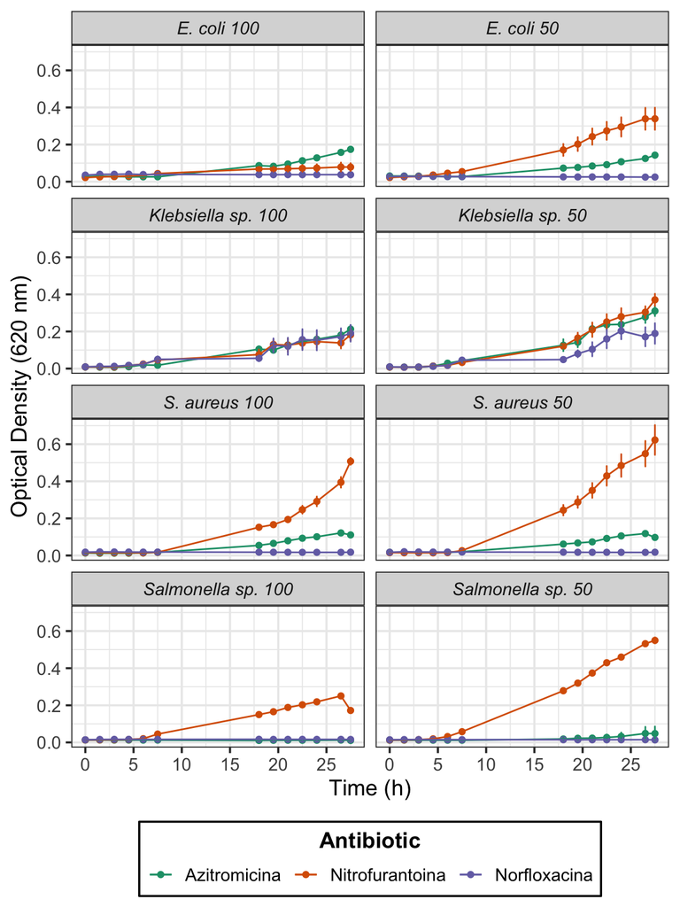

```r
Antibiotic_GG <- ggplot(tgc, aes(x = tiempo, y = abs, color = antibiotico, group = antibiotico)) +
  geom_point() +
  geom_line() +
  geom_errorbar(aes(ymin = abs - se, ymax = abs + se), width = 0.15) +
  facet_wrap(~bacteria_conc, ncol = 2) +
  labs(x = "Time (h)", y = "Optical Density (620 nm)") +
  scale_x_continuous(breaks = seq(0, max(tgc$tiempo), by = 5)) +
  scale_color_brewer(palette = "Dark2")+
  theme_bw(base_size = 14) +
  theme(legend.position = "bottom",
        legend.background = element_rect(color = "black"),
        strip.text = element_text(face = "italic"),
        legend.margin = margin(5, 5, 5, 5),
        legend.title = element_text(face = "bold", hjust = 0.5)) +
  guides(color = guide_legend(
    title = "Antibiotic", title.position = "top", title.hjust = 0.5, nrow = 1, ncol = 3))

Antibiotic_GG
```

```r
png("~/Desktop/CES/Master's Thesis/Antibiotic vs Bacteria.png", width = 150, height = 200, units = 'mm', res = 300)
Antibiotic_GG
dev.off()
```

**Interpretation**: Only two antibiotics appear to work properly. However, further testing revealed that the antibiotic activity of Norfloxacina was related to its preparation. As such, we will only use Azitromicina.

### Calothrix Performance

Moving on to evaluating the antibiotic capacity of `Calothrix sp`, first we subset the `Antibiotics` dataframe to only include the data for `Azitromicina` at a concentration of `50`. Next we use the `list` and `levels` functions again to rename the antibiotic. Next we use bracket notation to exclude columns we are not interested in. Next we use `colnames` to rename the new set of columns. Lastly, we reorder the columns so that we can match them with a different dataframe’s columns later on.

```r
Antibiotics2 <- subset(Antibiotics, antibiotico == "Azitromicina" & concentracion == 50)
levels(Antibiotics2$antibiotico) <- list("Azithromycin 50 mg/L"  = "Azitromicina")
Antibiotics2 <- Antibiotics2[,-c(3,6)]
colnames(Antibiotics2) <- c("tiempo", "tratamiento", "abs", "bacteria")
Antibiotics2 <- Antibiotics2[, c("tiempo", "tratamiento", "bacteria", "abs")]
```

In this block we first subset out the `antibiotico` from this `Calothrix2` dataframe, as this antbiotic did not perform as expected. We then rename the levels in the columns `bacteria` and `tratamiento`.

```r
Calothrix2 <- droplevels(subset(Calothrix, Calothrix$tratamiento != "antibiotico"))
levels(Calothrix2$bacteria) <- list("E. coli"  = "ecoli", "Klebsiella sp." = "klebsiella",
                             "Salmonella sp."  = "salmonella", "S. aureus" = "saureus")

levels(Calothrix2$tratamiento) <- list("Antibiotic"  = "antibiotico", "Growth Control" = "crecimiento",
                             "Calothrix [1]"  = "calothrix1",
                             "Calothrix [1/2]" = "calothrix1/2", "Calothrix [1/4]" = "calothrix1/4",
                             "Calothrix [1/8]" = "calothrix1/8", "Calothrix [1/16]" = "calothrix1/16")
```

We are now ready to combine our dataframes! We can do this easily using the `rbind` function.

```r
Calothrix3 <- rbind(Calothrix2, Antibiotics2)
```

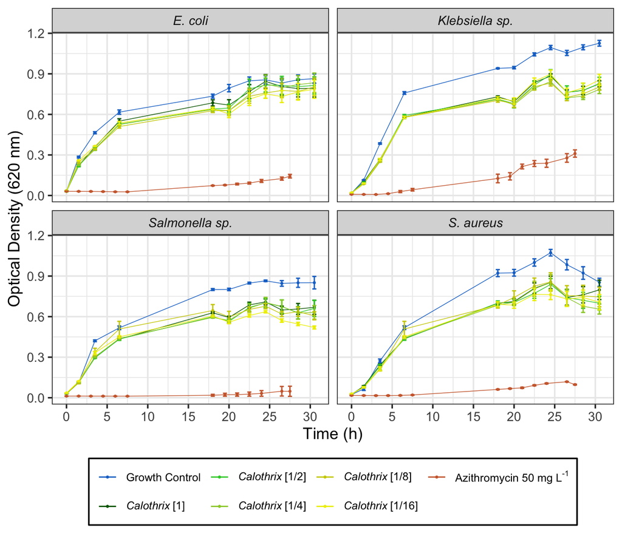

```r
tgc <- summarySE(Calothrix3, measurevar="abs", groupvars=c("tiempo", "tratamiento", "bacteria"), na.rm = TRUE)
tgc$tiempo <- as.numeric(as.character(tgc$tiempo))

color_map1 <- c("Azithromycin 50 mg/L" = "sienna3",
                "Growth Control" = "dodgerblue3",
                "Calothrix [1]"  = "darkgreen",
                "Calothrix [1/2]" = "green4",
                "Calothrix [1/4]" = "green3",
                "Calothrix [1/8]" = "yellowgreen",
                "Calothrix [1/16]" = "greenyellow")

color_map2 <- c("Azithromycin 50 mg/L" = "sienna3",
                "Growth Control" = "dodgerblue3",
                "Calothrix [1]"  = "darkgreen",
                "Calothrix [1/2]" = "limegreen",
                "Calothrix [1/4]" = "yellowgreen",
                "Calothrix [1/8]" = "yellow3",
                "Calothrix [1/16]" = "yellow2")


GG2B <- ggplot(tgc, aes(x = tiempo, y = abs, color = tratamiento, group = tratamiento)) +
  geom_point(size = 0.5) +
  geom_line(size = 0.25) +
  geom_errorbar(aes(ymin = abs - se, ymax = abs + se), width = 0.5) +
  facet_wrap(~bacteria) +
  labs(x = "Time (h)", y = "Optical Density (620 nm)") +
  scale_x_continuous(breaks = seq(0, max(tgc$tiempo), by = 5)) +
  theme_bw(base_size = 13) +
  scale_color_manual(
  values = color_map2,
  labels = c(
    "Growth Control",
    expression(italic("Calothrix") ~ "[1]"),
    expression(italic("Calothrix") ~ "[1/2]"),
    expression(italic("Calothrix") ~ "[1/4]"),
    expression(italic("Calothrix") ~ "[1/8]"),
    expression(italic("Calothrix") ~ "[1/16]"),
    expression("Azithromycin 50 mg L"^"-1")
  )
) +
  theme(legend.title.align=0.5) +
  theme(legend.position = "bottom",
        legend.background = element_rect(color = "black"),
        legend.justification = c("top"),
        legend.text = element_text(size = 9),
        strip.text = element_text(face = "italic")) +
  guides(color = guide_legend(title = NULL, nrow = 2, ncol = 4))

GG2B
```

```r
png("~/Desktop/CES/Manuscripts/Calothrix/Current Microbiology/Latex Version/Figures/Figure2.png",
    width = 168, height = 150, units = 'mm', res = 300)
GG2B
dev.off()
```

## Fungi Trial

### Antifungal Plot

To start us off, we rename the levels in the column `antibiotico` of the dataframe `Candida`.

```r
levels(Candida$antibiotico) <- list("Azitromicina"  = "azitromicina",
                                    "Nitrofurantoina" = "nitrofurantoina",
                                    "Norfloxacina"  = "norfloxacina")
```

Next, we calculate summary statistics using the `summarySE` function and save it as `tgc`. Selecting the `tiempo` column in `tgc`, we combine the `as.character` wrapped within `as.numeric` to ascertain that `tiempo` is properly coded as a numerical variable.

With that done, we are ready to graph using `ggplot`, once again incorporating the elements of `geom_point`, `geom_line`, `geom_errobar`, and `facet_wrap`. We save the graph as `Antifungal_GG` and export it using the `png` function.

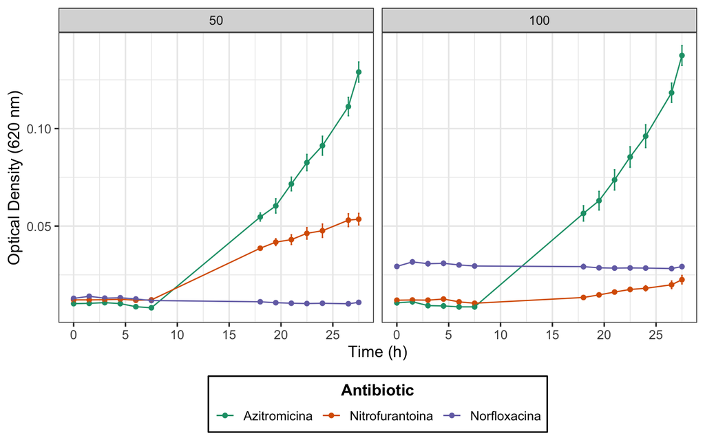

```r
tgc <- summarySE(Candida, measurevar="abs", groupvars=c("tiempo", "antibiotico", "concentracion"), na.rm = TRUE)
tgc$tiempo <- as.numeric(as.character(tgc$tiempo))

Antifungal_GG <- ggplot(tgc, aes(x = tiempo, y = abs, color = antibiotico, group = antibiotico)) +
  geom_point() +
  geom_line() +
  geom_errorbar(aes(ymin = abs - se, ymax = abs + se), width = 0.15) +
  facet_wrap(~concentracion) +
  labs(x = "Time (h)", y = "Optical Density (620 nm)") +
  scale_x_continuous(breaks = seq(0, max(tgc$tiempo), by = 5)) +
  scale_color_brewer(palette = "Dark2")+
  theme_bw(base_size = 13) +
  theme(legend.position = "bottom",
        legend.background = element_rect(color = "black"),
        legend.margin = margin(5, 5, 5, 5),
        legend.title = element_text(face = "bold", hjust = 0.5)) +
  guides(color = guide_legend(
    title = "Antibiotic", title.position = "top", title.hjust = 0.5, nrow = 1, ncol = 3))

Antifungal_GG
```

```r
png("~/Desktop/CES/Master's Thesis/Antibiotic vs Candida.png", width = 150, height = 100, units = 'mm', res = 300)
Antifungal_GG
dev.off()
```

### Candida performance

We then switch to the dataframe `Calbi`, which holds the `Calothrix` treatments. We subset out `antibiotico` because the antibiotic in this dataframe is not useable here.

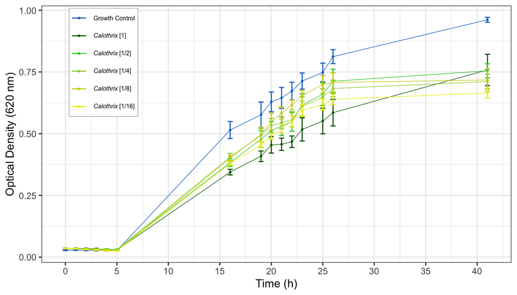

```r
Calbi2 <- droplevels(subset(Calbi, Calbi$tratamiento != "antibiotico"))

levels(Calbi2$tratamiento) <- list("Growth Control" = "crecimiento",
                             "Calothrix [1]"  = "calothrix1",
                             "Calothrix [1/2]" = "calothrix1/2",
                             "Calothrix [1/4]" = "calothrix1/4",
                             "Calothrix [1/8]" = "calothrix1/8",
                             "Calothrix [1/16]" = "calothrix1/16")

tgc <- summarySE(Calbi2, measurevar="abs", groupvars=c("tiempo", "tratamiento"), na.rm = TRUE)
tgc$tiempo <- as.numeric(as.character(tgc$tiempo))

GG2 <- ggplot(tgc, aes(x = tiempo, y = abs, color = tratamiento, group = tratamiento)) +
  geom_point(size= 0.5) +
  geom_line(size= 0.25) +
  geom_errorbar(aes(ymin = abs - se, ymax = abs + se), width = 0.5) +
  labs(x = "Time (h)", y = "Optical Density (620 nm)") +
  scale_x_continuous(breaks = seq(0, max(tgc$tiempo), by = 5)) +
  scale_color_manual(
    values = color_map2,
    labels = c(
      "Growth Control",
      expression(italic("Calothrix") ~ "[1]"),
      expression(italic("Calothrix") ~ "[1/2]"),
      expression(italic("Calothrix") ~ "[1/4]"),
      expression(italic("Calothrix") ~ "[1/8]"),
      expression(italic("Calothrix") ~ "[1/16]")
    )
  ) +
  theme_bw(base_size = 11) +
  theme(
    legend.title.align = 0.5,
    legend.position = c(0.132, 0.99),
    legend.margin = margin(1, 3, 1, 1),
    legend.background = element_rect(color = "black", size = 0.1),
    legend.justification = c("top"),
    strip.text = element_text(face = "italic"),
    legend.text = element_text(size = 6)
  ) +
  guides(color = guide_legend(title = NULL, nrow = 6, ncol = 1))

GG2
```

```r
png("~/Desktop/CES/Manuscripts/Calothrix/Current Microbiology/Latex Version/Figures/Figure3.png", width = 110, height = 75, units = 'mm', res = 300)
GG2
dev.off()
```

## Prebiotic Activity

To assess prebiotic activity in the dataframe `PreBio3` we need to first, rename the levels using the functions, `list` and `levels`, and then apply `summarySE` to calculate summary statistics. A color map is defined here as well. The names of bacteria are also rewritten.

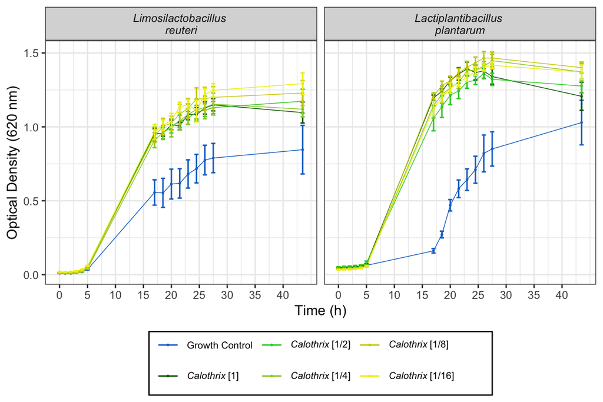

```r
levels(PreBio3$tratamiento) <- list("Growth Control" = "crecimiento",
                                   "Calothrix [1]"  = "calothrix1",
                                   "Calothrix [1/2]" = "calothrix1/2",
                                   "Calothrix [1/4]" = "calothrix1/4",
                                   "Calothrix [1/8]" = "calothrix1/8",
                                   "Calothrix [1/16]" = "calothrix1/16")

tgc <- summarySE(PreBio3, measurevar="abs", groupvars=c("tiempo", "tratamiento", "bacteria"), na.rm = TRUE)

color_map3 <- c("Growth Control" = "dodgerblue3",
                "Calothrix [1]"  = "darkgreen",
                "Calothrix [1/2]" = "limegreen",
                "Calothrix [1/4]" = "yellowgreen",
                "Calothrix [1/8]" = "yellow3",
                "Calothrix [1/16]" = "yellow2")

levels(tgc$bacteria) <- list("Limosilactobacillus \nreuteri" = "fos",
                                   "Lactiplantibacillus \nplantarum"  = "lp")

GG3 <- ggplot(tgc, aes(x = tiempo, y = abs, color = tratamiento, group = tratamiento)) +
  geom_point(size = 0.25) +
  geom_line(size = 0.25) +
  geom_errorbar(aes(ymin = abs - se, ymax = abs + se), width = 0.75) +
  facet_wrap(~bacteria) +
  labs(x = "Time (h)", y = "Optical Density (620 nm)") +
  scale_x_continuous(breaks = seq(0, max(tgc$tiempo), by = 5)) +
  theme_bw(base_size = 10) +
  scale_color_manual(
    values = color_map3,
    labels = c(
      "Growth Control",
      expression(italic("Calothrix") ~ "[1]"),
      expression(italic("Calothrix") ~ "[1/2]"),
      expression(italic("Calothrix") ~ "[1/4]"),
      expression(italic("Calothrix") ~ "[1/8]"),
      expression(italic("Calothrix") ~ "[1/16]")
    )
  ) +
  theme(
    legend.title.align = 0.5,
    legend.position = "bottom",
    legend.background = element_rect(color = "black"),
    legend.justification = c("top"),
    legend.margin = margin(1, 5, 5, 5),
    legend.text = element_text(size = 7),
    strip.text = element_text(face = "italic")
  ) +
  guides(color = guide_legend(title = NULL, nrow = 2, ncol = 4))

GG3
```

```r
png("~/Desktop/CES/Manuscripts/Calothrix/Current Microbiology/Latex Version/Figures/Figure4.png", width = 110, height = 75, units = 'mm', res = 300)
GG3
dev.off()
```

## Growth x Light

### Value Distribution

Let’s take a look at the data distribution of `peso_biomasa` in the `CaloGrowth` dataframe. To do this, we will create a histogram and a kernel density estimate, which is basically a smoothed histogram, using the `geom_histogram` and `geom_density` arguments from `ggplot.` We will also use `geom_vline` to create a vertical line at the mean.

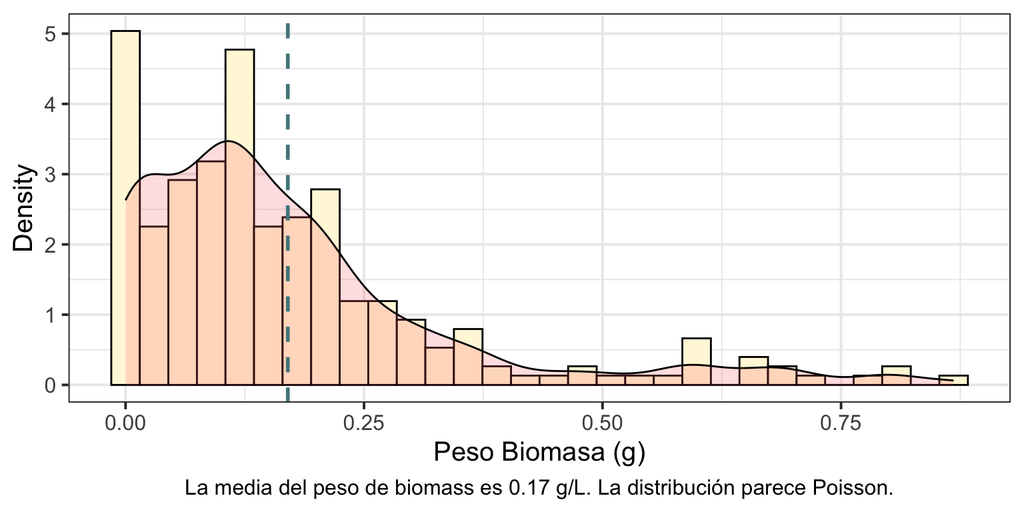

```r
ggplot(CaloGrowth, aes(x=peso_biomasa)) +
  geom_histogram(aes(y=..density..), colour="black", fill="cornsilk") +
  geom_density(alpha=.2, fill="#FF6666") + # easier to see distribution
  geom_vline(aes(xintercept=mean(peso_biomasa, na.rm=TRUE)),color="cadetblue4",
             linetype="dashed", size=1) + # This adds a blue line where the mean is.
  xlab("Peso Biomasa (g)") +
  ylab("Density") +
  labs(caption = "La media del peso de biomass es 0.17 g/L. La distribución parece Poisson.") +
  theme_bw(base_size = 15) +
  theme(plot.caption = element_text(hjust = 0.5)) # Centered caption
```

Let’s transform the variable `Day` into numerical using a combination of `as.character` and `as.numeric`.

```r
CaloGrowth$Day_N <- as.numeric(as.character(CaloGrowth$Day))
```

Next, we calculate a summary of the data using the `summarySE` function from the `Rmisc` package, specifying that we want to summarize the variable `peso_biomasa` grouped by the variables `medio`, `Day`, and `luz`. The `summarySE` function calculates the mean and standard error for each group. Then we reorder the levels of the variable `Day` in `tgc` using the `relevel` function. This is done to set a specific reference level for the variable `Day` in the graph later on.

### Light Graphs

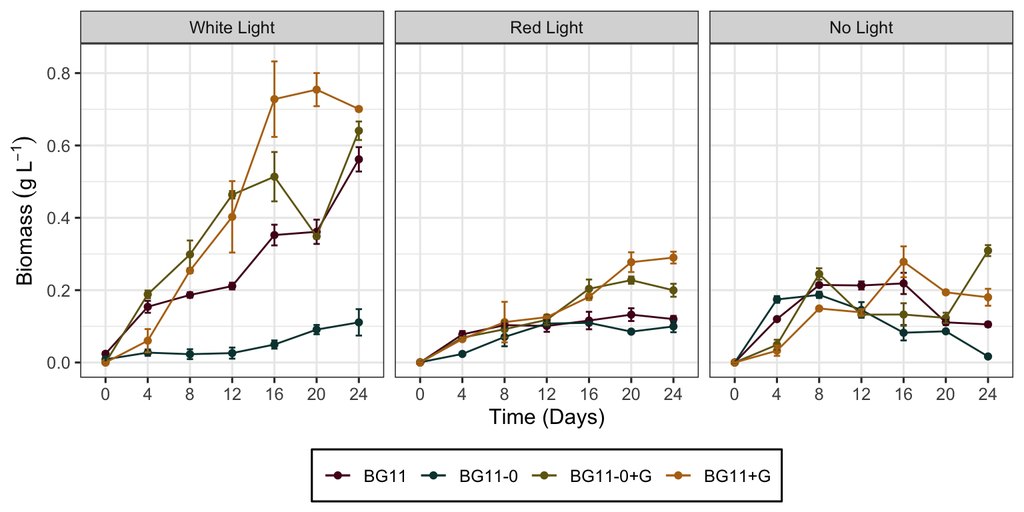

```r
tgc <- summarySE(CaloGrowth, measurevar="peso_biomasa", groupvars=c("medio", "Day", "luz"), na.rm = TRUE)
levels(tgc$luz) <- list("White Light"  = "Blanca",
                        "Red Light"  = "Roja",
                        "No Light" = "Oscuridad")

tgc <- summarySE(CaloGrowth, measurevar = "peso_biomasa", groupvars=c("medio", "Day", "luz"), na.rm = TRUE)
levels(tgc$luz) <- list("White Light" = "Blanca",
                        "Red Light" = "Roja",
                        "No Light" = "Oscuridad")

tgc$Day <- relevel(tgc$Day, ref = "24")
tgc$Day <- relevel(tgc$Day, ref = "20")
tgc$Day <- relevel(tgc$Day, ref = "16")
tgc$Day <- relevel(tgc$Day, ref = "12")
tgc$Day <- relevel(tgc$Day, ref = "8")
tgc$Day <- relevel(tgc$Day, ref = "4")
tgc$Day <- relevel(tgc$Day, ref = "0")

GG1 <- ggplot(tgc, aes(x = Day, y = peso_biomasa, color = medio, group = medio)) +
  geom_point() +
  geom_line() +
  geom_errorbar(aes(ymin = peso_biomasa - se, ymax = peso_biomasa + se), width = 0.15) +
  ylim(0,0.84) +
  facet_wrap(~luz) +
  xlab("Time (Days)") +
  ylab(expression(Biomass~(g~L^-1))) +  # Superscript in y-axis label
  theme_bw(base_size = 12) +
  scale_color_manual(values = c("#520120", "#08403E", "#706513", "#B57114")) +
  theme(legend.title.align=0.5) +
  theme(legend.position = "bottom",
        legend.background = element_rect(color = "black"),
        legend.justification = c("top")) +
    guides(color = guide_legend(title = NULL, nrow = 1, ncol = 4))
GG1
```

```r
png("~/Desktop/CES/Master's Thesis/Phycological Research/Figures/Figure 1 (Light Trials).png", width = 168, height = 100, units = 'mm', res = 300)
GG1
dev.off()
```

### Tables

To create the tables for the levels of luz, we will use the subset and droplevels functions, the first subset to remove the other levels of luz, and droplevels to ensure that zeros do not appear for the other levels.

```r
tgc_Blanca <- droplevels(subset(tgc, tgc$luz == "White Light"))
tgc_Roja <- droplevels(subset(tgc, tgc$luz == "Red Light"))
tgc_Oscuridad <- droplevels(subset(tgc, tgc$luz == "No Light"))
```

#### White Table

Next, we will remove columns that we are not interested in, round to two decimal places using the `round` function, convert the `Day` variable back to numeric, organize the table numerically with the arrange function, modify the column names with colnames, export the table with `write.csv`, and create the table in a professional style for the HTML report with `kbl`.

```r
tgc_Blanca <- tgc_Blanca[,c(1,2,5,7)]
tgc_Blanca$peso_biomasa <- round(tgc_Blanca$peso_biomasa,3)
tgc_Blanca$se <- round(tgc_Blanca$se,3)
tgc_Blanca$Day <- as.numeric(as.character(tgc_Blanca$Day))

tgc_Blanca <- tgc_Blanca %>%
  arrange(Day, medio)

colnames(tgc_Blanca) <- c("Medio", "Día", "Peso Biomasa (g/L)", "Error Estándar")

write.csv(tgc_Blanca, "~/Desktop/CES/Master's Thesis/Tabla_LuzBlanca.csv")
kbl(tgc_Blanca, format = "html",
    table.attr = "style='width:50%;'") %>%
  kable_classic() %>%
  scroll_box(height = "500px")
```

| Medio | Día | Peso Biomasa (g/L) | Error Estándar |
| --- | --- | --- | --- |
| BG11 | 0 | 0.024 | 0.005 |
| BG11-0 | 0 | 0.009 | 0.008 |
| BG11-0+G | 0 | 0.000 | 0.000 |
| BG11+G | 0 | 0.000 | 0.000 |
| BG11 | 4 | 0.154 | 0.017 |
| BG11-0 | 4 | 0.027 | 0.009 |
| BG11-0+G | 4 | 0.188 | 0.011 |
| BG11+G | 4 | 0.060 | 0.032 |
| BG11 | 8 | 0.187 | 0.008 |
| BG11-0 | 8 | 0.023 | 0.014 |
| BG11-0+G | 8 | 0.299 | 0.039 |
| BG11+G | 8 | 0.254 | 0.007 |
| BG11 | 12 | 0.211 | 0.009 |
| BG11-0 | 12 | 0.026 | 0.015 |
| BG11-0+G | 12 | 0.464 | 0.010 |
| BG11+G | 12 | 0.403 | 0.099 |
| BG11 | 16 | 0.352 | 0.029 |
| BG11-0 | 16 | 0.050 | 0.011 |
| BG11-0+G | 16 | 0.514 | 0.068 |
| BG11+G | 16 | 0.728 | 0.104 |
| BG11 | 20 | 0.361 | 0.034 |
| BG11-0 | 20 | 0.091 | 0.013 |
| BG11-0+G | 20 | 0.349 | 0.007 |
| BG11+G | 20 | 0.754 | 0.046 |
| BG11 | 24 | 0.562 | 0.034 |
| BG11-0 | 24 | 0.111 | 0.036 |
| BG11-0+G | 24 | 0.641 | 0.026 |
| BG11+G | 24 | 0.701 | 0.005 |

#### Red Table

```r
tgc_Roja <- tgc_Roja[,c(1,2,5,7)]
tgc_Roja$peso_biomasa <- round(tgc_Roja$peso_biomasa,3)
tgc_Roja$se <- round(tgc_Roja$se,3)
tgc_Roja$Day <- as.numeric(as.character(tgc_Roja$Day))

tgc_Roja <- tgc_Roja %>%
  dplyr::arrange(Day, medio)

colnames(tgc_Roja) <- c("Medio", "Día", "Peso Biomasa (g/L)", "Error Estándar")

write.csv(tgc_Roja, "~/Desktop/CES/Master's Thesis/Tabla_LuzRoja.csv")
kbl(tgc_Roja, format = "html",
    table.attr = "style='width:50%;'") %>%
  kable_classic() %>%
  scroll_box(height = "500px")
```

| Medio | Día | Peso Biomasa (g/L) | Error Estándar |
| --- | --- | --- | --- |
| BG11 | 0 | 0.000 | 0.000 |
| BG11-0 | 0 | 0.001 | 0.000 |
| BG11-0+G | 0 | 0.000 | 0.000 |
| BG11+G | 0 | 0.000 | 0.000 |
| BG11 | 4 | 0.078 | 0.009 |
| BG11-0 | 4 | 0.024 | 0.002 |
| BG11-0+G | 4 | 0.069 | 0.001 |
| BG11+G | 4 | 0.065 | 0.004 |
| BG11 | 8 | 0.103 | 0.005 |
| BG11-0 | 8 | 0.071 | 0.026 |
| BG11-0+G | 8 | 0.092 | 0.023 |
| BG11+G | 8 | 0.112 | 0.056 |
| BG11 | 12 | 0.101 | 0.016 |
| BG11-0 | 12 | 0.108 | 0.007 |
| BG11-0+G | 12 | 0.118 | 0.014 |
| BG11+G | 12 | 0.125 | 0.002 |
| BG11 | 16 | 0.116 | 0.024 |
| BG11-0 | 16 | 0.110 | 0.003 |
| BG11-0+G | 16 | 0.204 | 0.026 |
| BG11+G | 16 | 0.181 | 0.009 |
| BG11 | 20 | 0.132 | 0.018 |
| BG11-0 | 20 | 0.085 | 0.004 |
| BG11-0+G | 20 | 0.228 | 0.010 |
| BG11+G | 20 | 0.277 | 0.027 |
| BG11 | 24 | 0.120 | 0.009 |
| BG11-0 | 24 | 0.100 | 0.016 |
| BG11-0+G | 24 | 0.200 | 0.018 |
| BG11+G | 24 | 0.290 | 0.016 |

#### Darkness Table

```r
tgc_Oscuridad <- tgc_Oscuridad[,c(1,2,5,7)]
tgc_Oscuridad$peso_biomasa <- round(tgc_Oscuridad$peso_biomasa,3)
tgc_Oscuridad$se <- round(tgc_Oscuridad$se,3)
tgc_Oscuridad$Day <- as.numeric(as.character(tgc_Oscuridad$Day))

tgc_Oscuridad <- tgc_Oscuridad %>%
  dplyr::arrange(Day, medio)

colnames(tgc_Oscuridad) <- c("Medio", "Día", "Peso Biomasa (g/L)", "Error Estándar")

write.csv(tgc_Oscuridad, "~/Desktop/CES/Master's Thesis/Tabla_LuzOscuridad.csv")
kbl(tgc_Oscuridad, format = "html",
    table.attr = "style='width:50%;'") %>%
  kable_classic() %>%
  scroll_box(height = "500px")
```

| Medio | Día | Peso Biomasa (g/L) | Error Estándar |
| --- | --- | --- | --- |
| BG11 | 0 | 0.000 | 0.000 |
| BG11-0 | 0 | 0.000 | 0.000 |
| BG11-0+G | 0 | 0.000 | 0.000 |
| BG11+G | 0 | 0.000 | 0.000 |
| BG11 | 4 | 0.120 | 0.001 |
| BG11-0 | 4 | 0.174 | 0.009 |
| BG11-0+G | 4 | 0.049 | 0.014 |
| BG11+G | 4 | 0.033 | 0.014 |
| BG11 | 8 | 0.214 | 0.004 |
| BG11-0 | 8 | 0.187 | 0.009 |
| BG11-0+G | 8 | 0.245 | 0.016 |
| BG11+G | 8 | 0.149 | 0.002 |
| BG11 | 12 | 0.213 | 0.011 |
| BG11-0 | 12 | 0.145 | 0.022 |
| BG11-0+G | 12 | 0.132 | 0.006 |
| BG11+G | 12 | 0.139 | 0.009 |
| BG11 | 16 | 0.219 | 0.029 |
| BG11-0 | 16 | 0.082 | 0.021 |
| BG11-0+G | 16 | 0.133 | 0.031 |
| BG11+G | 16 | 0.278 | 0.043 |
| BG11 | 20 | 0.111 | 0.007 |
| BG11-0 | 20 | 0.086 | 0.003 |
| BG11-0+G | 20 | 0.123 | 0.014 |
| BG11+G | 20 | 0.194 | 0.006 |
| BG11 | 24 | 0.105 | 0.006 |
| BG11-0 | 24 | 0.017 | 0.003 |
| BG11-0+G | 24 | 0.309 | 0.015 |
| BG11+G | 24 | 0.180 | 0.023 |

# Analysis

The following graph is a distribution density graph useful for evaluating the behavior of data. This may hint to use whether we should analyze the data using parametric or non-parametric statistics.

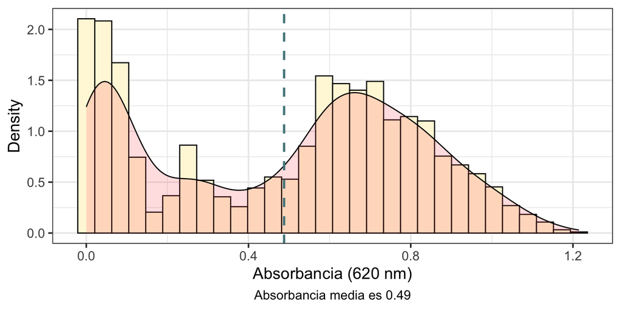

```r
x_mean <- round(mean(Calothrix3$abs, na.rm = TRUE), 2)
ggplot(Calothrix3, aes(x=abs)) +
  geom_histogram(aes(y=..density..), colour="black", fill="cornsilk") +
  geom_density(alpha=.2, fill="#FF6666") + # easier to see distribution
  geom_vline(aes(xintercept=mean(abs, na.rm=TRUE)),color="cadetblue4",
             linetype="dashed", size=1) + # This adds a blue line where the mean is.
  xlab("Absorbancia (620 nm)") +
  ylab("Density") +
  labs(caption = paste0("Absorbancia media es ", x_mean)) +
  theme_bw(base_size = 15) +
  theme(plot.caption = element_text(hjust = 0.5))
```

**Interpretation**: The density distribution graph is bimodal and right-skewed. This means that even transformation are unlikely to fix the behavior of residuals. Considering this distribution and the wealth of data, we will opt for a more conservative approach using non-parametric statistics.

To prepare for the statistical analysis, first we create subsets for every level of `bacteria` in `Calothrix3`.

```r
Calo_coli <- droplevels(subset(Calothrix3, Calothrix3$bacteria == "E. coli"))
Calo_kleb <- droplevels(subset(Calothrix3, Calothrix3$bacteria == "Klebsiella sp."))
Calo_salm <- droplevels(subset(Calothrix3, Calothrix3$bacteria == "Salmonella sp."))
Calo_saur <- droplevels(subset(Calothrix3, Calothrix3$bacteria == "S. aureus"))
```

## E. coli Inhibition

```r
profile <- tweedie.profile(abs ~ tratamiento * tiempo, data = Calo_coli,
                           p.vec = seq(1.1, 1.9, by = 0.1), method = "series")
```

```
## 1.1 1.2 1.3 1.4 1.5 1.6 1.7 1.8 1.9
## .........Done.
```

```r
profile$p.max
```

```
## [1] 1.9
```

This suggests that Gamma is probably appropriate…

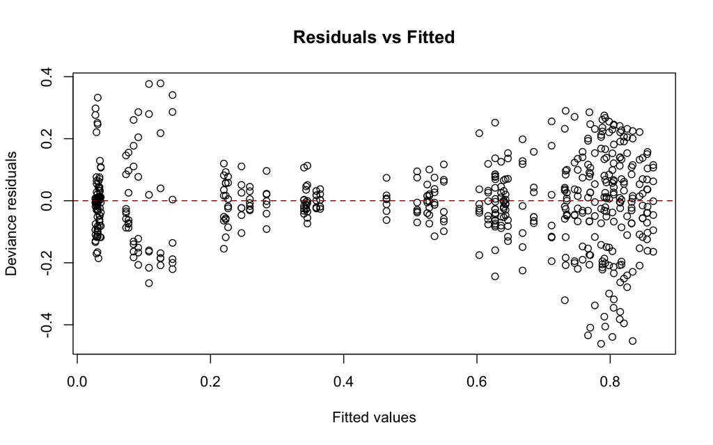

```r
glm_gamma <- glm(abs ~ tratamiento * tiempo, data = Calo_coli, family = Gamma(link = "log"))

plot(fitted(glm_gamma), residuals(glm_gamma, type = "deviance"),
     xlab = "Fitted values", ylab = "Deviance residuals",
     main = "Residuals vs Fitted")
abline(h = 0, col = "darkred", lty = 2)
```

```r
anova(glm_gamma)
```

```
## Analysis of Deviance Table
##
## Model: Gamma, link: log
##
## Response: abs
##
## Terms added sequentially (first to last)
##
##
##                    Df Deviance Resid. Df Resid. Dev        F    Pr(>F)
## NULL                                 552     485.97
## tratamiento         6  221.804       546     264.17 1805.763 < 2.2e-16 ***
## tiempo             18  229.905       528      34.26  623.903 < 2.2e-16 ***
## tratamiento:tiempo 54   24.372       474       9.89   22.046 < 2.2e-16 ***
## ---
## Signif. codes:  0 '***' 0.001 '**' 0.01 '*' 0.05 '.' 0.1 ' ' 1
```

```r
glm_gamma2 <- glm(abs ~ tratamiento + tiempo, data = Calo_coli, family = Gamma(link = "log"))
anova(glm_gamma2)
```

```
## Analysis of Deviance Table
##
## Model: Gamma, link: log
##
## Response: abs
##
## Terms added sequentially (first to last)
##
##
##             Df Deviance Resid. Df Resid. Dev      F    Pr(>F)
## NULL                          552     485.97
## tratamiento  6    221.8       546     264.17 458.58 < 2.2e-16 ***
## tiempo      18    229.9       528      34.26 158.44 < 2.2e-16 ***
## ---
## Signif. codes:  0 '***' 0.001 '**' 0.01 '*' 0.05 '.' 0.1 ' ' 1
```

```r
library(emmeans)
# Run the emmeans contrasts
contrast_results <- emmeans(glm_gamma2, pairwise ~ tratamiento | tiempo, adjust = "BH")$contrasts

# Convert to data frame
contrast_df <- as.data.frame(contrast_results)

class(contrast_df)
```

```
## [1] "summary_emm" "data.frame"
```

```r
filtered_contrast_df <- subset(
  contrast_df,
  p.value <= 0.1 | p.value == "<.0001"
)
```

Now, what we will use is the `Conover Post-Hoc Test`, available using the `conover.test` package. However, we will also use a for loop to perform the conover test for each level of `tiempo`. We will store the result in a list for easier viewing. We will start off using the E. coli dataset, saved in the `Calo_coli` dataframe.

```r
tiempo_levels <- unique(Calo_coli$tiempo)
conover_results <- list()

for (level in tiempo_levels) {
  data_subset <- Calo_coli[Calo_coli$tiempo == level, ]

  if (length(unique(data_subset$tratamiento)) > 1) {
    cat("Conover test for tiempo:", level, "\n")
    conover_result <- conover.test(data_subset$abs, data_subset$tratamiento, method = "bh",
                                   list = TRUE, table = FALSE)
    conover_results[[as.character(level)]] <- conover_result
  } else {
    cat("Skipping tiempo:", level, "- not enough groups for test.\n")
    conover_results[[as.character(level)]] <- NULL
  }
}
```

```
## Conover test for tiempo: 0
##   Kruskal-Wallis rank sum test
##
## data: x and group
## Kruskal-Wallis chi-squared = 21.9202, df = 6, p-value = 0
##
##
##                            Comparison of x by group
##                              (Benjamini-Hochberg)
##
## List of pairwise comparisons: t statistic (adjusted p-value)
## -------------------------------------------------------------
## Azithromycin 50 mg/L - Calothrix [1]    : -3.121822 (0.0057)*
## Azithromycin 50 mg/L - Calothrix [1/16] : -1.590586 (0.1138)
## Calothrix [1] - Calothrix [1/16]        :  1.531235 (0.1166)
## Azithromycin 50 mg/L - Calothrix [1/2]  : -2.623280 (0.0159)*
## Calothrix [1] - Calothrix [1/2]         :  0.498541 (0.3430)
## Calothrix [1/16] - Calothrix [1/2]      : -1.032693 (0.2019)
## Azithromycin 50 mg/L - Calothrix [1/4]  :  0.759682 (0.2635)
## Calothrix [1] - Calothrix [1/4]         :  3.881505 (0.0013)*
## Calothrix [1/16] - Calothrix [1/4]      :  2.350269 (0.0275)
## Calothrix [1/2] - Calothrix [1/4]       :  3.382963 (0.0033)*
## Azithromycin 50 mg/L - Calothrix [1/8]  : -3.905245 (0.0018)*
## Calothrix [1] - Calothrix [1/8]         : -0.783423 (0.2704)
## Calothrix [1/16] - Calothrix [1/8]      : -2.314658 (0.0269)
## Calothrix [1/2] - Calothrix [1/8]       : -1.281964 (0.1671)
## Calothrix [1/4] - Calothrix [1/8]       : -4.664928 (0.0003)*
## Azithromycin 50 mg/L - Growth Control   : -2.813200 (0.0111)*
## Calothrix [1] - Growth Control          :  0.308621 (0.3985)
## Calothrix [1/16] - Growth Control       : -1.222614 (0.1712)
## Calothrix [1/2] - Growth Control        : -0.189920 (0.4251)
## Calothrix [1/4] - Growth Control        : -3.572883 (0.0024)*
## Calothrix [1/8] - Growth Control        :  1.092044 (0.1967)
##
## alpha = 0.05
## Reject Ho if p <= alpha/2
## Conover test for tiempo: 1.5
##   Kruskal-Wallis rank sum test
##
## data: x and group
```

[output cut: 313 more lines]

```
## Calothrix [1/16] - Growth Control  : -0.766648 (1.0000)
## Calothrix [1/2] - Growth Control   : -0.497285 (0.7775)
## Calothrix [1/4] - Growth Control   : -0.082880 (0.5391)
## Calothrix [1/8] - Growth Control   : -0.580166 (0.8481)
##
## alpha = 0.05
## Reject Ho if p <= alpha/2
## Skipping tiempo: 3 - not enough groups for test.
## Skipping tiempo: 4.5 - not enough groups for test.
## Skipping tiempo: 6 - not enough groups for test.
## Skipping tiempo: 7.5 - not enough groups for test.
## Skipping tiempo: 19.5 - not enough groups for test.
## Skipping tiempo: 21 - not enough groups for test.
## Skipping tiempo: 24 - not enough groups for test.
## Skipping tiempo: 27.5 - not enough groups for test.
```

```r
# Initialize an empty data.frame
conover_df <- data.frame()

# Loop over the stored results and combine them
for (level in names(conover_results)) {
  res <- conover_results[[level]]

  if (!is.null(res)) {
    df <- as.data.frame(res)
    df$tiempo <- level
    conover_df <- rbind(conover_df, df)
  }
}

# Clean column names if needed (e.g., from rownames)
conover_df$contrast <- rownames(conover_df)
rownames(conover_df) <- NULL

# Convert p-values where possible, and assign 0.0001 to those listed as "<.0001"
conover_df$p_value <- suppressWarnings(as.numeric(conover_df$P.adjusted))
conover_df$p_value[is.na(conover_df$p_value) & grepl("<", conover_df$P.adjusted)] <- 0.0001

# Filter for adjusted p-values ≤ 0.1
conover_filtered <- conover_df[conover_df$p_value <= 0.1, ]

# Filter for p <= 0.1 or p adj reported as "<.0001"
conover_filtered <- conover_df[conover_df$p_value <= 0.1, ]

# Show result
conover_filtered
```

```
##         chi2          T            P   P.adjusted
## 1   21.92018  -3.121822 1.624237e-03 5.684830e-03
## 4   21.92018  -2.623280 6.042797e-03 1.586234e-02
## 8   21.92018   3.881505 1.802789e-04 1.261952e-03
## 9   21.92018   2.350269 1.176627e-02 2.745463e-02
## 10  21.92018   3.382963 7.812061e-04 3.281066e-03
## 11  21.92018  -3.905245 1.677897e-04 1.761792e-03
## 13  21.92018  -2.314659 1.279585e-02 2.687128e-02
## 15  21.92018  -4.664928 1.567671e-05 3.292109e-04
## 16  21.92018  -2.813201 3.714774e-03 1.114432e-02
## 20  21.92018  -3.572884 4.512912e-04 2.369279e-03
## 22  38.97295  -4.317081 4.716023e-05 9.003316e-05
## 23  38.97295  -9.481439 2.683486e-12 2.817660e-11
## 24  38.97295  -5.164358 3.116868e-06 8.181780e-06
## 25  38.97295  -4.075001 9.996125e-05 1.614759e-04
```

[output cut: 147 more lines]

## Klebsiella Inhibition

For Klebsiella too, stored in the dataframe `Calo_kleb`, we will perform looped Conover Post-Hoc Tests.

```r
tiempo_levels <- unique(Calo_kleb$tiempo)
# Initialize a list to store the test results
conover_results <- list()

# Perform Conover test for each level of tiempo
for (level in tiempo_levels) {
  # Subset data for the current level of tiempo
  data_subset <- Calo_kleb[Calo_kleb$tiempo == level, ]

  # Print the current level of tiempo
  cat("Conover test for tiempo:", level, "\n")

  # Perform Conover test
  conover_result <- conover.test(data_subset$abs, data_subset$tratamiento, method = "bh", list = TRUE)

  # Store the result in the list
  conover_results[[as.character(level)]] <- conover_result
}
```

```
## Conover test for tiempo: 0
##   Kruskal-Wallis rank sum test
##
## data: x and group
## Kruskal-Wallis chi-squared = 35.3702, df = 6, p-value = 0
##
##
##                            Comparison of x by group
##                              (Benjamini-Hochberg)
## Col Mean-|
## Row Mean |   Azithrom   Calothri   Calothri   Calothri   Calothri   Calothri
## ---------+------------------------------------------------------------------
## Calothri |  -5.290144
##          |    0.0000*
## Calothri |  -9.334546  -4.044401
##          |    0.0000*    0.0003*
## Calothri |  -3.839621   1.450523   5.494924
##          |    0.0004*     0.0853    0.0000*
## Calothri |  -6.945448  -1.655303   2.389097  -3.105827
##          |    0.0000*     0.0614    0.0150*    0.0030*
## Calothri |  -7.064903  -1.774758   2.269642  -3.225281  -0.119454
##          |    0.0000*     0.0514    0.0187*    0.0023*     0.4527
## Growth C |  -2.645072   2.645072   6.689473   1.194548   4.300375   4.419830
##          |    0.0086*    0.0092*    0.0000*     0.1255    0.0001*    0.0001*
##
##
## List of pairwise comparisons: t statistic (adjusted p-value)
## -------------------------------------------------------------
## Azithromycin 50 mg/L - Calothrix [1]    : -5.290144 (0.0000)*
## Azithromycin 50 mg/L - Calothrix [1/16] : -9.334546 (0.0000)*
## Calothrix [1] - Calothrix [1/16]        : -4.044401 (0.0003)*
## Azithromycin 50 mg/L - Calothrix [1/2]  : -3.839621 (0.0004)*
## Calothrix [1] - Calothrix [1/2]         :  1.450523 (0.0853)
## Calothrix [1/16] - Calothrix [1/2]      :  5.494924 (0.0000)*
## Azithromycin 50 mg/L - Calothrix [1/4]  : -6.945448 (0.0000)*
## Calothrix [1] - Calothrix [1/4]         : -1.655303 (0.0614)
## Calothrix [1/16] - Calothrix [1/4]      :  2.389097 (0.0150)*
## Calothrix [1/2] - Calothrix [1/4]       : -3.105827 (0.0030)*
## Azithromycin 50 mg/L - Calothrix [1/8]  : -7.064903 (0.0000)*
## Calothrix [1] - Calothrix [1/8]         : -1.774758 (0.0514)
```

[output cut: 474 more lines]

```
## Calothrix [1/2] - Calothrix [1/8]  :  0.195619 (0.4230)
## Calothrix [1/4] - Calothrix [1/8]  : -0.810425 (0.3173)
## Calothrix [1] - Growth Control     : -3.716777 (0.0013)*
## Calothrix [1/16] - Growth Control  : -3.381429 (0.0026)*
## Calothrix [1/2] - Growth Control   : -4.080071 (0.0006)*
## Calothrix [1/4] - Growth Control   : -5.086116 (0.0001)*
## Calothrix [1/8] - Growth Control   : -4.275691 (0.0005)*
##
## alpha = 0.05
## Reject Ho if p <= alpha/2
## Conover test for tiempo: 3
##   Kruskal-Wallis rank sum test
##
## data: x and group
## Kruskal-Wallis chi-squared = 0, df = 0, p-value = 1
```

```
## Error in Psort[1, i]: subscript out of bounds
```

## Salmonella Inhibition

For Salmonella too, stored in the dataframe `Calo_salm`, we will perform looped Conover Post-Hoc Tests.

```r
tiempo_levels <- unique(Calo_salm$tiempo)
# Initialize a list to store the test results
conover_results <- list()

# Perform Conover test for each level of tiempo
for (level in tiempo_levels) {
  # Subset data for the current level of tiempo
  data_subset <- Calo_salm[Calo_salm$tiempo == level, ]

  # Print the current level of tiempo
  cat("Conover test for tiempo:", level, "\n")

  # Perform Conover test
  conover_result <- conover.test(data_subset$abs, data_subset$tratamiento, method = "bh", list = TRUE)

  # Store the result in the list
  conover_results[[as.character(level)]] <- conover_result
}
```

```
## Conover test for tiempo: 0
##   Kruskal-Wallis rank sum test
##
## data: x and group
## Kruskal-Wallis chi-squared = 37.8125, df = 6, p-value = 0
##
##
##                            Comparison of x by group
##                              (Benjamini-Hochberg)
## Col Mean-|
## Row Mean |   Azithrom   Calothri   Calothri   Calothri   Calothri   Calothri
## ---------+------------------------------------------------------------------
## Calothri |  -5.717316
##          |    0.0000*
## Calothri |  -10.75083  -5.033518
##          |    0.0000*    0.0000*
## Calothri |  -6.856981  -1.139664   3.893853
##          |    0.0000*     0.1370    0.0004*
## Calothri |  -3.286032   2.431284   7.464802   3.570948
##          |    0.0017*    0.0127*    0.0000*    0.0008*
## Calothri |  -8.718433  -3.001116   2.032401  -1.861452  -5.432400
##          |    0.0000*    0.0032*     0.0299     0.0385    0.0000*
## Growth C |  -3.760892   1.956424   6.989942   3.096088  -0.474860   4.957540
##          |    0.0005*     0.0333    0.0000*    0.0026*     0.3187    0.0000*
##
##
## List of pairwise comparisons: t statistic (adjusted p-value)
## -------------------------------------------------------------
## Azithromycin 50 mg/L - Calothrix [1]    : -5.717316 (0.0000)*
## Azithromycin 50 mg/L - Calothrix [1/16] : -10.75083 (0.0000)*
## Calothrix [1] - Calothrix [1/16]        : -5.033518 (0.0000)*
## Azithromycin 50 mg/L - Calothrix [1/2]  : -6.856981 (0.0000)*
## Calothrix [1] - Calothrix [1/2]         : -1.139664 (0.1370)
## Calothrix [1/16] - Calothrix [1/2]      :  3.893853 (0.0004)*
## Azithromycin 50 mg/L - Calothrix [1/4]  : -3.286032 (0.0017)*
## Calothrix [1] - Calothrix [1/4]         :  2.431284 (0.0127)*
## Calothrix [1/16] - Calothrix [1/4]      :  7.464802 (0.0000)*
## Calothrix [1/2] - Calothrix [1/4]       :  3.570948 (0.0008)*
## Azithromycin 50 mg/L - Calothrix [1/8]  : -8.718433 (0.0000)*
## Calothrix [1] - Calothrix [1/8]         : -3.001116 (0.0032)*
```

[output cut: 474 more lines]

```
## Calothrix [1/2] - Calothrix [1/8]  :  0.418211 (0.3913)
## Calothrix [1/4] - Calothrix [1/8]  :  0.139403 (0.4450)
## Calothrix [1] - Growth Control     : -2.230460 (0.0343)
## Calothrix [1/16] - Growth Control  : -5.436746 (0.0000)*
## Calothrix [1/2] - Growth Control   : -2.927478 (0.0088)*
## Calothrix [1/4] - Growth Control   : -3.206286 (0.0070)*
## Calothrix [1/8] - Growth Control   : -3.345690 (0.0072)*
##
## alpha = 0.05
## Reject Ho if p <= alpha/2
## Conover test for tiempo: 3
##   Kruskal-Wallis rank sum test
##
## data: x and group
## Kruskal-Wallis chi-squared = 0, df = 0, p-value = 1
```

```
## Error in Psort[1, i]: subscript out of bounds
```

## S. saureus Inhibition

For S. saureus too, stored in the dataframe `Calo_saur`, we will perform looped Conover Post-Hoc Tests.

```r
tiempo_levels <- unique(Calo_saur$tiempo)
# Initialize a list to store the test results
conover_results <- list()

# Perform Conover test for each level of tiempo
for (level in tiempo_levels) {
  # Subset data for the current level of tiempo
  data_subset <- Calo_saur[Calo_saur$tiempo == level, ]

  # Print the current level of tiempo
  cat("Conover test for tiempo:", level, "\n")

  # Perform Conover test
  conover_result <- conover.test(data_subset$abs, data_subset$tratamiento, method = "bh", list = TRUE)

  # Store the result in the list
  conover_results[[as.character(level)]] <- conover_result
}
```

```
## Conover test for tiempo: 0
##   Kruskal-Wallis rank sum test
##
## data: x and group
## Kruskal-Wallis chi-squared = 17.4398, df = 6, p-value = 0.01
##
##
##                            Comparison of x by group
##                              (Benjamini-Hochberg)
## Col Mean-|
## Row Mean |   Azithrom   Calothri   Calothri   Calothri   Calothri   Calothri
## ---------+------------------------------------------------------------------
## Calothri |  -2.939642
##          |    0.0186*
## Calothri |  -4.233962  -1.294320
##          |    0.0013*     0.1520
## Calothri |  -2.424107   0.515534   1.809854
##          |     0.0345     0.3552     0.1017
## Calothri |  -3.740365  -0.800723   0.493596  -1.316257
##          |    0.0029*     0.2642     0.3449     0.1577
## Calothri |  -2.895766   0.043875   1.338195  -0.471659   0.844598
##          |    0.0157*     0.4826     0.1795     0.3358     0.2645
## Growth C |  -1.579509   1.360132   2.654452   0.844598   2.160856   1.316257
##          |     0.1420     0.1901    0.0235*     0.2822     0.0547     0.1708
##
##
## List of pairwise comparisons: t statistic (adjusted p-value)
## -------------------------------------------------------------
## Azithromycin 50 mg/L - Calothrix [1]    : -2.939642 (0.0186)*
## Azithromycin 50 mg/L - Calothrix [1/16] : -4.233962 (0.0013)*
## Calothrix [1] - Calothrix [1/16]        : -1.294320 (0.1520)
## Azithromycin 50 mg/L - Calothrix [1/2]  : -2.424107 (0.0345)
## Calothrix [1] - Calothrix [1/2]         :  0.515534 (0.3552)
## Calothrix [1/16] - Calothrix [1/2]      :  1.809854 (0.1017)
## Azithromycin 50 mg/L - Calothrix [1/4]  : -3.740365 (0.0029)*
## Calothrix [1] - Calothrix [1/4]         : -0.800723 (0.2642)
## Calothrix [1/16] - Calothrix [1/4]      :  0.493596 (0.3449)
## Calothrix [1/2] - Calothrix [1/4]       : -1.316257 (0.1577)
## Azithromycin 50 mg/L - Calothrix [1/8]  : -2.895766 (0.0157)*
## Calothrix [1] - Calothrix [1/8]         :  0.043875 (0.4826)
```

[output cut: 474 more lines]

```
## Calothrix [1/2] - Calothrix [1/8]  : -0.402246 (0.3980)
## Calothrix [1/4] - Calothrix [1/8]  : -0.916228 (0.3428)
## Calothrix [1] - Growth Control     : -0.692757 (0.3697)
## Calothrix [1/16] - Growth Control  : -1.743068 (0.2246)
## Calothrix [1/2] - Growth Control   : -1.810109 (0.2949)
## Calothrix [1/4] - Growth Control   : -2.324090 (0.1941)
## Calothrix [1/8] - Growth Control   : -1.407862 (0.2516)
##
## alpha = 0.05
## Reject Ho if p <= alpha/2
## Conover test for tiempo: 3
##   Kruskal-Wallis rank sum test
##
## data: x and group
## Kruskal-Wallis chi-squared = 0, df = 0, p-value = 1
```

```
## Error in Psort[1, i]: subscript out of bounds
```

## Candida Inhibition

For Candida too, stored in the dataframe `Calbi2`, we will perform looped Conover Post-Hoc Tests.

```r
tiempo_levels <- unique(Calbi2$tiempo)
# Initialize a list to store the test results
conover_results <- list()

# Perform Conover test for each level of tiempo
for (level in tiempo_levels) {
  # Subset data for the current level of tiempo
  data_subset <- Calbi2[Calbi2$tiempo == level, ]

  # Print the current level of tiempo
  cat("Conover test for tiempo:", level, "\n")

  # Perform Conover test
  conover_result <- conover.test(data_subset$abs, data_subset$tratamiento, method = "bh", list = TRUE)

  # Store the result in the list
  conover_results[[as.character(level)]] <- conover_result
}
```

```
## Conover test for tiempo: 0
##   Kruskal-Wallis rank sum test
##
## data: x and group
## Kruskal-Wallis chi-squared = 14.1425, df = 5, p-value = 0.01
##
##
##                            Comparison of x by group
##                              (Benjamini-Hochberg)
## Col Mean-|
## Row Mean |   Calothri   Calothri   Calothri   Calothri   Calothri
## ---------+-------------------------------------------------------
## Calothri |   0.176614
##          |     0.4966
## Calothri |  -0.201844  -0.378458
##          |     0.5257     0.5894
## Calothri |  -0.555072  -0.731686  -0.353228
##          |     0.5459     0.5864     0.5445
## Calothri |   0.025230  -0.151383   0.227075   0.580303
##          |     0.4900     0.4717     0.5602     0.6057
## Growth C |   3.204283   3.027669   3.406128   3.759356   3.179053
##          |    0.0071*    0.0068*    0.0061*    0.0045*    0.0057*
##
##
## List of pairwise comparisons: t statistic (adjusted p-value)
## --------------------------------------------------------
## Calothrix [1] - Calothrix [1/16]   :  0.176614 (0.4966)
## Calothrix [1] - Calothrix [1/2]    : -0.201844 (0.5257)
## Calothrix [1/16] - Calothrix [1/2] : -0.378458 (0.5894)
## Calothrix [1] - Calothrix [1/4]    : -0.555072 (0.5459)
## Calothrix [1/16] - Calothrix [1/4] : -0.731686 (0.5864)
## Calothrix [1/2] - Calothrix [1/4]  : -0.353228 (0.5445)
## Calothrix [1] - Calothrix [1/8]    :  0.025230 (0.4900)
## Calothrix [1/16] - Calothrix [1/8] : -0.151383 (0.4717)
## Calothrix [1/2] - Calothrix [1/8]  :  0.227075 (0.5602)
## Calothrix [1/4] - Calothrix [1/8]  :  0.580303 (0.6057)
## Calothrix [1] - Growth Control     :  3.204283 (0.0071)*
## Calothrix [1/16] - Growth Control  :  3.027669 (0.0068)*
## Calothrix [1/2] - Growth Control   :  3.406128 (0.0061)*
## Calothrix [1/4] - Growth Control   :  3.759356 (0.0045)*
```

[output cut: 605 more lines]

```
## Calothrix [1] - Calothrix [1/4]    :  0.263992 (0.4250)
## Calothrix [1/16] - Calothrix [1/4] : -1.267161 (0.1999)
## Calothrix [1/2] - Calothrix [1/4]  :  0.871173 (0.2655)
## Calothrix [1] - Calothrix [1/8]    :  0.395988 (0.4006)
## Calothrix [1/16] - Calothrix [1/8] : -1.135165 (0.2198)
## Calothrix [1/2] - Calothrix [1/8]  :  1.003169 (0.2419)
## Calothrix [1/4] - Calothrix [1/8]  :  0.131996 (0.4479)
## Calothrix [1] - Growth Control     : -3.088707 (0.0072)*
## Calothrix [1/16] - Growth Control  : -4.619861 (0.0004)*
## Calothrix [1/2] - Growth Control   : -2.481525 (0.0268)
## Calothrix [1/4] - Growth Control   : -3.352699 (0.0047)*
## Calothrix [1/8] - Growth Control   : -3.484695 (0.0049)*
##
## alpha = 0.05
## Reject Ho if p <= alpha/2
```

## Prebiotic Activity

### FOS

For `Limosilactobacillus reuteri` too, stored in the dataframe `PreBio3_fos`, we will perform looped Conover Post-Hoc Tests.

```r
PreBio3_fos <- droplevels(subset(PreBio3, PreBio3$bacteria != "fos"))

tiempo_levels <- unique(PreBio3_fos$tiempo)
# Initialize a list to store the test results
conover_results <- list()

# Perform Conover test for each level of tiempo
for (level in tiempo_levels) {
  # Subset data for the current level of tiempo
  data_subset <- PreBio3_fos[PreBio3_fos$tiempo == level, ]

  # Print the current level of tiempo
  cat("Conover test for tiempo:", level, "\n")

  # Perform Conover test
  conover_result <- conover.test(data_subset$abs, data_subset$tratamiento, method = "bh", list = TRUE)

  # Store the result in the list
  conover_results[[as.character(level)]] <- conover_result
}
```

```
## Conover test for tiempo: 0
##   Kruskal-Wallis rank sum test
##
## data: x and group
## Kruskal-Wallis chi-squared = 21.1201, df = 5, p-value = 0
##
##
##                            Comparison of x by group
##                              (Benjamini-Hochberg)
## Col Mean-|
## Row Mean |   Calothri   Calothri   Calothri   Calothri   Calothri
## ---------+-------------------------------------------------------
## Calothri |   3.534068
##          |    0.0029*
## Calothri |  -1.495746  -5.029815
##          |     0.0896    0.0001*
## Calothri |   1.671717  -1.862351   3.167464
##          |     0.0704     0.0663    0.0047*
## Calothri |   1.803694  -1.730373   3.299441   0.131977
##          |     0.0664     0.0691    0.0041*     0.4479
## Growth C |  -1.202463  -4.736532   0.293283  -2.874180  -3.006158
##          |     0.1368    0.0001*     0.4130    0.0072*    0.0060*
##
##
## List of pairwise comparisons: t statistic (adjusted p-value)
## --------------------------------------------------------
## Calothrix [1] - Calothrix [1/16]   :  3.534068 (0.0029)*
## Calothrix [1] - Calothrix [1/2]    : -1.495746 (0.0896)
## Calothrix [1/16] - Calothrix [1/2] : -5.029815 (0.0001)*
## Calothrix [1] - Calothrix [1/4]    :  1.671717 (0.0704)
## Calothrix [1/16] - Calothrix [1/4] : -1.862351 (0.0663)
## Calothrix [1/2] - Calothrix [1/4]  :  3.167464 (0.0047)*
## Calothrix [1] - Calothrix [1/8]    :  1.803694 (0.0664)
## Calothrix [1/16] - Calothrix [1/8] : -1.730373 (0.0691)
## Calothrix [1/2] - Calothrix [1/8]  :  3.299441 (0.0041)*
## Calothrix [1/4] - Calothrix [1/8]  :  0.131977 (0.4479)
## Calothrix [1] - Growth Control     : -1.202463 (0.1368)
## Calothrix [1/16] - Growth Control  : -4.736532 (0.0001)*
## Calothrix [1/2] - Growth Control   :  0.293283 (0.4130)
## Calothrix [1/4] - Growth Control   : -2.874180 (0.0072)*
```

[output cut: 605 more lines]

```
## Calothrix [1] - Calothrix [1/4]    : -1.562303 (0.1587)
## Calothrix [1/16] - Calothrix [1/4] : -0.118356 (0.4856)
## Calothrix [1/2] - Calothrix [1/4]  : -1.538632 (0.1421)
## Calothrix [1] - Calothrix [1/8]    : -1.822687 (0.1437)
## Calothrix [1/16] - Calothrix [1/8] : -0.378740 (0.4419)
## Calothrix [1/2] - Calothrix [1/8]  : -1.799016 (0.1206)
## Calothrix [1/4] - Calothrix [1/8]  : -0.260383 (0.4593)
## Calothrix [1] - Growth Control     :  0.946850 (0.2387)
## Calothrix [1/16] - Growth Control  :  2.390797 (0.0554)
## Calothrix [1/2] - Growth Control   :  0.970521 (0.2537)
## Calothrix [1/4] - Growth Control   :  2.509153 (0.0628)
## Calothrix [1/8] - Growth Control   :  2.769537 (0.0661)
##
## alpha = 0.05
## Reject Ho if p <= alpha/2
```

### LP

```r
PreBio3_lp <- droplevels(subset(PreBio3, PreBio3$bacteria != "lp"))

tiempo_levels <- unique(PreBio3_lp$tiempo)
# Initialize a list to store the test results
conover_results <- list()

# Perform Conover test for each level of tiempo
for (level in tiempo_levels) {
  # Subset data for the current level of tiempo
  data_subset <- PreBio3_lp[PreBio3_lp$tiempo == level, ]

  # Print the current level of tiempo
  cat("Conover test for tiempo:", level, "\n")

  # Perform Conover test
  conover_result <- conover.test(data_subset$abs, data_subset$tratamiento, method = "bh", list = TRUE)

  # Store the result in the list
  conover_results[[as.character(level)]] <- conover_result
}
```

```
## Conover test for tiempo: 0
##   Kruskal-Wallis rank sum test
##
## data: x and group
## Kruskal-Wallis chi-squared = 7.5775, df = 5, p-value = 0.18
##
##
##                            Comparison of x by group
##                              (Benjamini-Hochberg)
## Col Mean-|
## Row Mean |   Calothri   Calothri   Calothri   Calothri   Calothri
## ---------+-------------------------------------------------------
## Calothri |  -2.272577
##          |     0.1092
## Calothri |  -0.192208   2.080369
##          |     0.4896     0.1117
## Calothri |   0.180901   2.453478   0.373109
##          |     0.4594     0.1434     0.4849
## Calothri |  -0.791444   1.481132  -0.599236  -0.972346
##          |     0.4649     0.2209     0.5182     0.4217
## Growth C |  -0.248739   2.023837  -0.056531  -0.429641   0.542705
##          |     0.5031     0.0946     0.4776     0.5025     0.4922
##
##
## List of pairwise comparisons: t statistic (adjusted p-value)
## -------------------------------------------------------
## Calothrix [1] - Calothrix [1/16]   : -2.272577 (0.1092)
## Calothrix [1] - Calothrix [1/2]    : -0.192208 (0.4896)
## Calothrix [1/16] - Calothrix [1/2] :  2.080369 (0.1117)
## Calothrix [1] - Calothrix [1/4]    :  0.180901 (0.4594)
## Calothrix [1/16] - Calothrix [1/4] :  2.453478 (0.1434)
## Calothrix [1/2] - Calothrix [1/4]  :  0.373109 (0.4849)
## Calothrix [1] - Calothrix [1/8]    : -0.791444 (0.4649)
## Calothrix [1/16] - Calothrix [1/8] :  1.481132 (0.2209)
## Calothrix [1/2] - Calothrix [1/8]  : -0.599236 (0.5182)
## Calothrix [1/4] - Calothrix [1/8]  : -0.972346 (0.4217)
## Calothrix [1] - Growth Control     : -0.248739 (0.5031)
## Calothrix [1/16] - Growth Control  :  2.023837 (0.0946)
## Calothrix [1/2] - Growth Control   : -0.056531 (0.4776)
## Calothrix [1/4] - Growth Control   : -0.429641 (0.5025)
```

[output cut: 605 more lines]

```
## Calothrix [1] - Calothrix [1/4]    : -0.045040 (0.4822)
## Calothrix [1/16] - Calothrix [1/4] :  1.441288 (0.2372)
## Calothrix [1/2] - Calothrix [1/4]  :  0.517963 (0.3506)
## Calothrix [1] - Calothrix [1/8]    : -1.283647 (0.2593)
## Calothrix [1/16] - Calothrix [1/8] :  0.202681 (0.4503)
## Calothrix [1/2] - Calothrix [1/8]  : -0.720644 (0.3244)
## Calothrix [1/4] - Calothrix [1/8]  : -1.238607 (0.2395)
## Calothrix [1] - Growth Control     :  0.878285 (0.2892)
## Calothrix [1/16] - Growth Control  :  2.364614 (0.1767)
## Calothrix [1/2] - Growth Control   :  1.441288 (0.2965)
## Calothrix [1/4] - Growth Control   :  0.923325 (0.3394)
## Calothrix [1/8] - Growth Control   :  2.161933 (0.1401)
##
## alpha = 0.05
## Reject Ho if p <= alpha/2
```

## Complete Light Model

```r
lm1 <- lm(data = CaloGrowth, peso_biomasa ~ Day_N + luz + nitrogeno * glucosa)
plot(lm1)
summary(pairs(emmeans(lm1, ~ luz), adjust = "tukey"))
```

```
##  contrast           estimate     SE  df t.ratio p.value
##  Blanca - Oscuridad    0.139 0.0183 245   7.598  <.0001
##  Blanca - Roja         0.158 0.0183 245   8.633  <.0001
##  Oscuridad - Roja      0.019 0.0183 245   1.034  0.5559
##
## Results are averaged over the levels of: nitrogeno, glucosa
## P value adjustment: tukey method for comparing a family of 3 estimates
```

[output not shown]

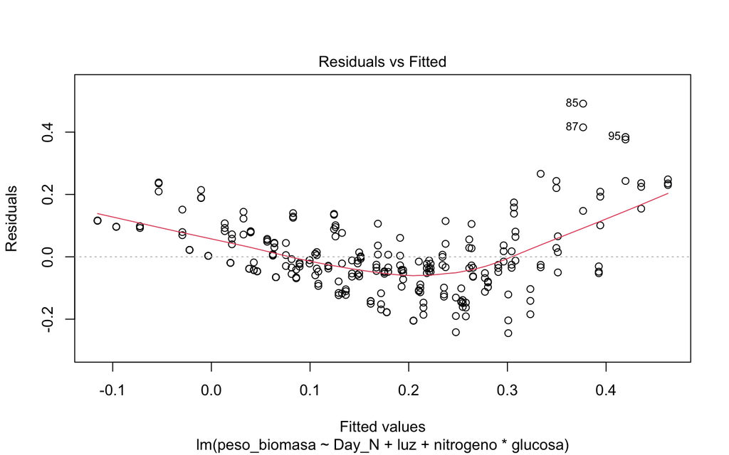

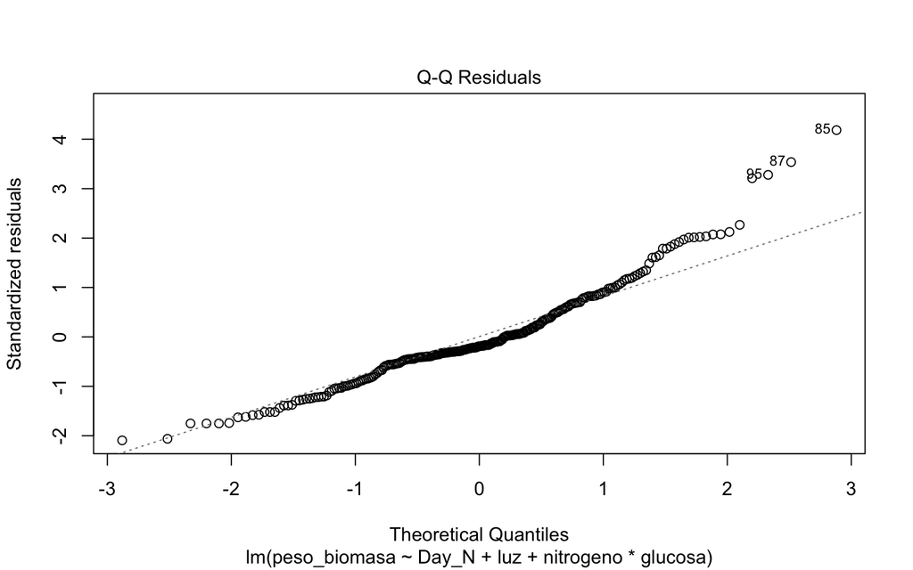

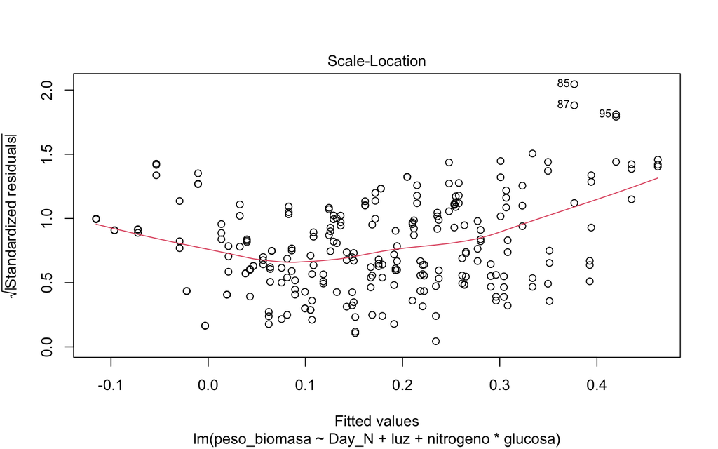

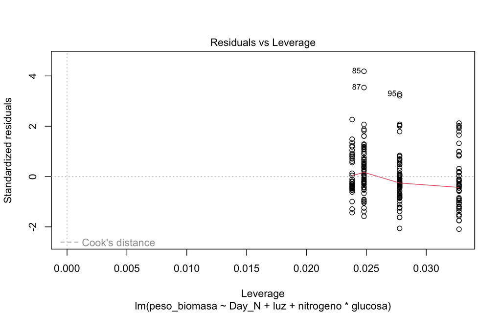

```r
lm3 <- lm(data = CaloGrowth, peso_biomasa ~ Day_N + luz)
summary(pairs(emmeans(lm3, ~ luz), adjust = "tukey"))
```

[output not shown]

## Transformed Light Model

Let’s attempt a square root transformation.

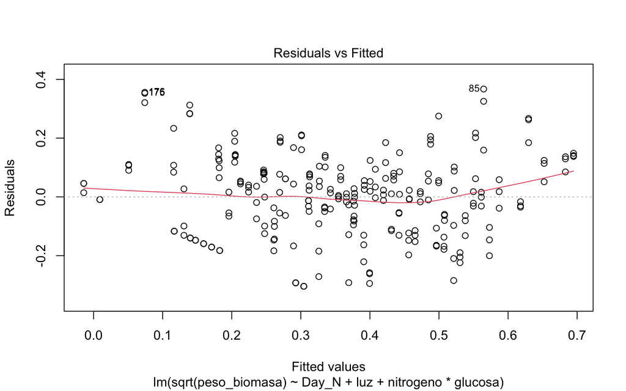

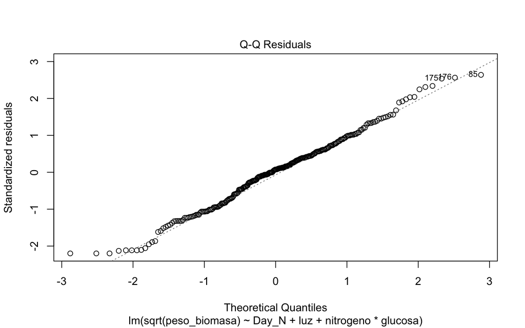

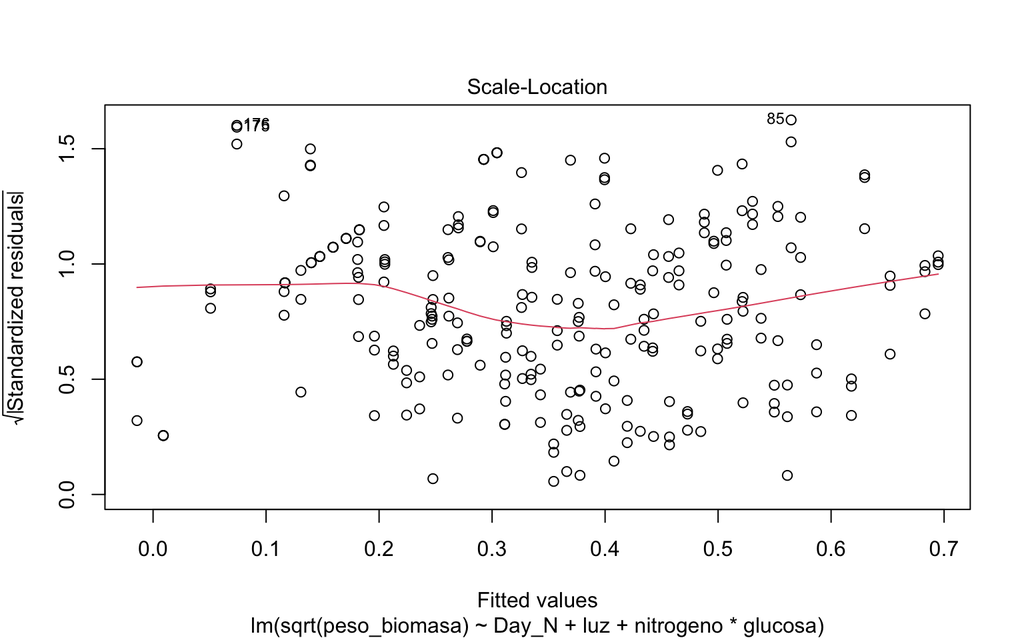

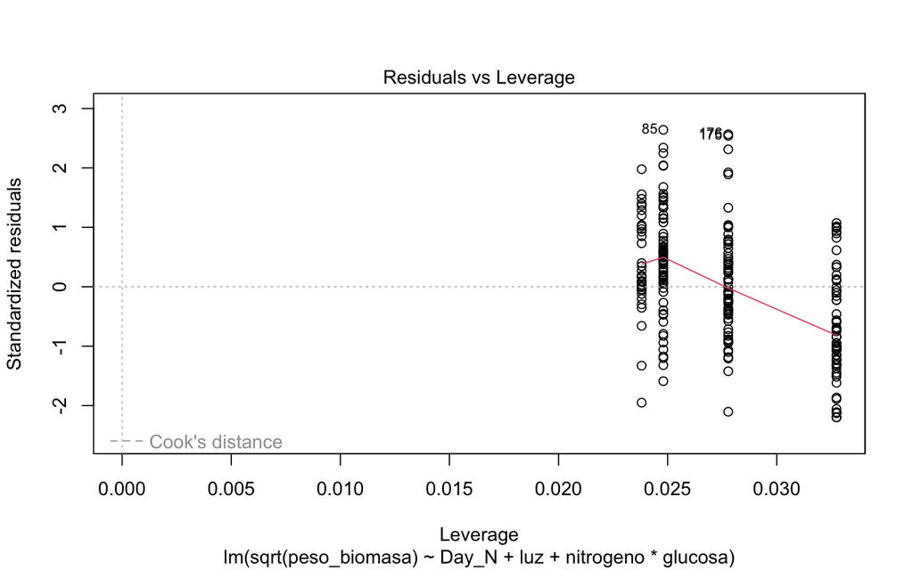

```r
lm2 <- lm(data = CaloGrowth, sqrt(peso_biomasa) ~ Day_N + luz + nitrogeno * glucosa)
plot(lm2)
```

The residuals look better! Ok, time to separate by light (`luz`).

```r
Nost_Blanca <- droplevels(subset(CaloGrowth, CaloGrowth$luz == "Blanca"))
Nost_Oscuri <- droplevels(subset(CaloGrowth, CaloGrowth$luz == "Oscuridad"))
Nost_Roja <- droplevels(subset(CaloGrowth, CaloGrowth$luz == "Roja"))
```

We can evaluate the model with the `anova` function. The result will provide us with an analysis of the variance of the model coefficients, allowing us to determine if any of the predictors significantly contribute to explaining the variability in the response variable. The obtained p-values will indicate the significance of each term in the model in relation to the response variable.

#### White Light

```r
lm_Blanca <- lm(data = Nost_Blanca, peso_biomasa ~ Day_N + nitrogeno * glucosa)
anova(lm_Blanca)
```

```
## Analysis of Variance Table
##
## Response: peso_biomasa
##                   Df  Sum Sq Mean Sq  F value    Pr(>F)
## Day_N              1 2.20676 2.20676 136.7046 < 2.2e-16 ***
## nitrogeno          1 0.41188 0.41188  25.5151 2.763e-06 ***
## glucosa            1 1.07395 1.07395  66.5292 4.318e-12 ***
## nitrogeno:glucosa  1 0.12236 0.12236   7.5801   0.00732 **
## Residuals         79 1.27526 0.01614
## ---
## Signif. codes:  0 '***' 0.001 '**' 0.01 '*' 0.05 '.' 0.1 ' ' 1
```

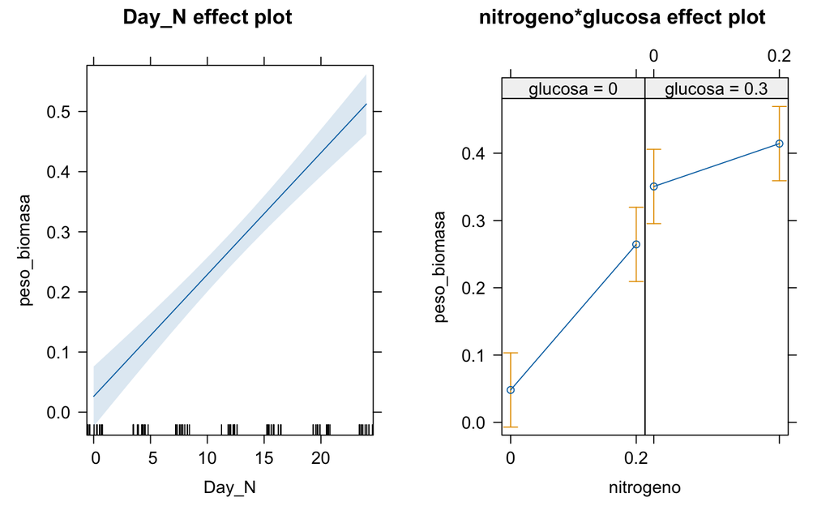

```r
plot(allEffects(lm_Blanca))
```

What we can see from the `summary` function and the `effects` graphs is a significant interaction between `glucose` and `nitrogen` on `biomass` (F<sub>1,79</sub> = 7.58, p = **0.0073**). We can obtain further insight on the nature of the interaction by splitting the model for each level of glucose and each level of nitrogen.

##### White Light x Nitrogen by Glucose

```r
options(digits = 6)

Nost_Blanca$glucosa_factor <- as.factor(Nost_Blanca$glucosa)

models <- by(Nost_Blanca, Nost_Blanca$glucosa_factor, function(subset) {
  lm(peso_biomasa ~ Day_N + nitrogeno, data = subset)
})

lapply(models, summary)
```

```
## $`0`
##
## Call:
## lm(formula = peso_biomasa ~ Day_N + nitrogeno, data = subset)
##
## Residuals:
##     Min      1Q  Median      3Q     Max
## -0.1343 -0.0472 -0.0209  0.0595  0.1963
##
## Coefficients:
##              Estimate Std. Error t value Pr(>|t|)
## (Intercept)   -0.0941     0.0248   -3.80    5e-04 ***
## Day_N          0.0118     0.0015    7.89  1.3e-09 ***
## nitrogeno0.2   0.2164     0.0240    9.00  4.6e-11 ***
## ---
## Signif. codes:  0 '***' 0.001 '**' 0.01 '*' 0.05 '.' 0.1 ' ' 1
##
## Residual standard error: 0.0779 on 39 degrees of freedom
## Multiple R-squared:  0.786,  Adjusted R-squared:  0.775
## F-statistic: 71.6 on 2 and 39 DF,  p-value: 8.73e-14
##
##
## $`0.3`
##
## Call:
## lm(formula = peso_biomasa ~ Day_N + nitrogeno, data = subset)
##
## Residuals:
##     Min      1Q  Median      3Q     Max
## -0.2399 -0.0702 -0.0146  0.0928  0.3390
##
## Coefficients:
##              Estimate Std. Error t value Pr(>|t|)
## (Intercept)   0.00652    0.04133    0.16     0.88
## Day_N         0.02867    0.00251   11.44    5e-14 ***
## nitrogeno0.2  0.06371    0.04010    1.59     0.12
## ---
## Signif. codes:  0 '***' 0.001 '**' 0.01 '*' 0.05 '.' 0.1 ' ' 1
##
## Residual standard error: 0.13 on 39 degrees of freedom
## Multiple R-squared:  0.774,  Adjusted R-squared:  0.762
## F-statistic: 66.7 on 2 and 39 DF,  p-value: 2.59e-13
```

##### White Light x Glucose by Nitrogen

```r
Nost_Blanca$nitrogeno_factor <- as.factor(Nost_Blanca$nitrogeno)

models <- by(Nost_Blanca, Nost_Blanca$nitrogeno_factor, function(subset) {
  lm(peso_biomasa ~ Day_N + glucosa, data = subset)
})

lapply(models, summary)
```

```
## $`0`
##
## Call:
## lm(formula = peso_biomasa ~ Day_N + glucosa, data = subset)
##
## Residuals:
##     Min      1Q  Median      3Q     Max
## -0.1942 -0.0693 -0.0246  0.0916  0.1903
##
## Coefficients:
##             Estimate Std. Error t value Pr(>|t|)
## (Intercept) -0.10830    0.03425   -3.16    0.003 **
## Day_N        0.01303    0.00208    6.28  2.1e-07 ***
## glucosa0.3   0.30248    0.03322    9.10  3.4e-11 ***
## ---
## Signif. codes:  0 '***' 0.001 '**' 0.01 '*' 0.05 '.' 0.1 ' ' 1
##
## Residual standard error: 0.108 on 39 degrees of freedom
## Multiple R-squared:  0.758,  Adjusted R-squared:  0.746
## F-statistic: 61.1 on 2 and 39 DF,  p-value: 9.51e-13
##
##
## $`0.2`
##
## Call:
## lm(formula = peso_biomasa ~ Day_N + glucosa, data = subset)
##
## Residuals:
##     Min      1Q  Median      3Q     Max
## -0.1884 -0.0782 -0.0338  0.0709  0.3438
##
## Coefficients:
##             Estimate Std. Error t value Pr(>|t|)
## (Intercept) -0.06538    0.03751   -1.74  0.08925 .
## Day_N        0.02749    0.00227   12.08  9.3e-15 ***
## glucosa0.3   0.14981    0.03639    4.12  0.00019 ***
## ---
## Signif. codes:  0 '***' 0.001 '**' 0.01 '*' 0.05 '.' 0.1 ' ' 1
##
## Residual standard error: 0.118 on 39 degrees of freedom
## Multiple R-squared:  0.807,  Adjusted R-squared:  0.797
## F-statistic: 81.5 on 2 and 39 DF,  p-value: 1.18e-14
```

#### Red Light

```r
lm_Roja <- lm(data = Nost_Roja, peso_biomasa ~ Day_N + nitrogeno * glucosa)
anova(lm_Roja)
```

```
## Analysis of Variance Table
##
## Response: peso_biomasa
##                   Df  Sum Sq Mean Sq F value   Pr(>F)
## Day_N              1 0.29792 0.29792 153.495  < 2e-16 ***
## nitrogeno          1 0.00924 0.00924   4.761   0.0321 *
## glucosa            1 0.07070 0.07070  36.428 4.86e-08 ***
## nitrogeno:glucosa  1 0.00002 0.00002   0.008   0.9272
## Residuals         79 0.15333 0.00194
## ---
## Signif. codes:  0 '***' 0.001 '**' 0.01 '*' 0.05 '.' 0.1 ' ' 1
```

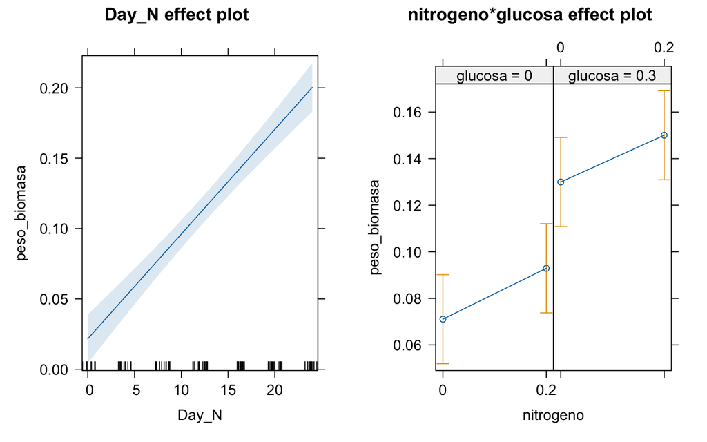

```r
plot(allEffects(lm_Roja))
```

- Under `Red Light` conditions, we do not have a significant interaction between `Nitrogen` and `Glucose` on `Biomass` (F<sub>1,79</sub> = 0.008, p = **0.927**). We can proceed with a model that does not the interaction so we can obtain coefficients for the main effects.

##### Red Light No Interaction

```r
lm_Roja2 <- lm(data = Nost_Roja, peso_biomasa ~ Day_N + nitrogeno + glucosa)
summary(lm_Roja2)
```

```
##
## Call:
## lm(formula = peso_biomasa ~ Day_N + nitrogeno + glucosa, data = Nost_Roja)
##
## Residuals:
##      Min       1Q   Median       3Q      Max
## -0.10571 -0.03060  0.00139  0.02541  0.10696
##
## Coefficients:
##               Estimate Std. Error t value Pr(>|t|)
## (Intercept)  -0.017842   0.010945   -1.63    0.107
## Day_N         0.007444   0.000597   12.47   <2e-16 ***
## nitrogeno0.2  0.020976   0.009554    2.20    0.031 *
## glucosa0.3    0.058024   0.009554    6.07    4e-08 ***
## ---
## Signif. codes:  0 '***' 0.001 '**' 0.01 '*' 0.05 '.' 0.1 ' ' 1
##
## Residual standard error: 0.0438 on 80 degrees of freedom
## Multiple R-squared:  0.711,  Adjusted R-squared:   0.7
## F-statistic: 65.7 on 3 and 80 DF,  p-value: <2e-16
```

- Under `Red Light` conditions, CaloGrowth `Biomass (g/l)` increases per day 0.007 ± 0.001 (t = 12.47, p < **2e-16**).
- Under `Red Light` conditions, CaloGrowth `Biomass (g/l)` is affected when `Nitrogen 0.2` is added 0.021 ± 0.009 (t = 2.20, p = **0.031**).
- Under `Red Light` conditions, CaloGrowth `Biomass (g/l)` increases when `Glucose 0.3` is added 0.058 ± 0.01 (t = 6.07, p = **4e-08**).

#### No Light

```r
lm_Oscu <- lm(data = Nost_Oscuri, peso_biomasa ~ Day_N + nitrogeno * glucosa)
anova(lm_Oscu)
```

```
## Analysis of Variance Table
##
## Response: peso_biomasa
##                   Df Sum Sq Mean Sq F value   Pr(>F)
## Day_N              1 0.1103 0.11027  16.959 9.33e-05 ***
## nitrogeno          1 0.0079 0.00795   1.222    0.272
## glucosa            1 0.0090 0.00903   1.389    0.242
## nitrogeno:glucosa  1 0.0102 0.01019   1.567    0.214
## Residuals         79 0.5137 0.00650
## ---
## Signif. codes:  0 '***' 0.001 '**' 0.01 '*' 0.05 '.' 0.1 ' ' 1
```

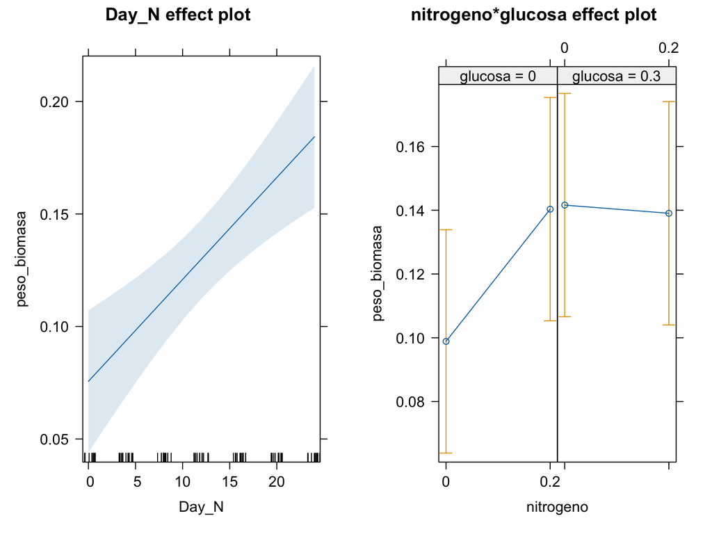

```r
plot(allEffects(lm_Oscu))
```

- Under `No Light` conditions, we do not have a significant interaction between `Nitrogen` and `Glucose` on `Biomass` (F<sub>1,79</sub> = 1.567, p = **0.214**). We can proceed with a model that does not the interaction so we can obtain coefficients for the main effects.

##### No Light No Interaction

```r
lm_Oscu2 <- lm(data = Nost_Oscuri, peso_biomasa ~ Day_N + nitrogeno + glucosa)
summary(lm_Oscu2)
```

```
##
## Call:
## lm(formula = peso_biomasa ~ Day_N + nitrogeno + glucosa, data = Nost_Oscuri)
##
## Residuals:
##      Min       1Q   Median       3Q      Max
## -0.15322 -0.06518 -0.00802  0.06304  0.18382
##
## Coefficients:
##              Estimate Std. Error t value Pr(>|t|)
## (Intercept)   0.05552    0.02023    2.74   0.0075 **
## Day_N         0.00453    0.00110    4.10  9.7e-05 ***
## nitrogeno0.2  0.01945    0.01766    1.10   0.2739
## glucosa0.3    0.02074    0.01766    1.17   0.2437
## ---
## Signif. codes:  0 '***' 0.001 '**' 0.01 '*' 0.05 '.' 0.1 ' ' 1
##
## Residual standard error: 0.0809 on 80 degrees of freedom
## Multiple R-squared:  0.195,  Adjusted R-squared:  0.165
## F-statistic: 6.48 on 3 and 80 DF,  p-value: 0.000557
```

- Under `No Light` conditions, CaloGrowth `Biomass (g/l)` increases per day 0.005 ± 0.001 (t = 4.104, p = **9.7e-05**).
- Under `No Light` conditions, CaloGrowth `Biomass (g/l)` is not affected when `Nitrogen 0.2` is added 0.019 ± 0.018 (t = 1.102, p = **0.274**).
- Under `No Light` conditions, CaloGrowth `Biomass (g/l)` is not affected when `Glucose 0.3` is added 0.021 ± 0.018 (t = 1.174, p = **0.244**).

# Package Report

Below you will find the specifications on the software and R packages used to create this report.

```
## Analyses were conducted using the R Statistical language (version 4.4.1; R Core
## Team, 2024) on macOS 15.6.1, using the packages conover.test (version 1.1.6;
## Dinno A, 2024), tweedie (version 2.3.5; Dunn PK, Smyth GK, 2005), effects
## (version 4.2.2; Fox J, Weisberg S, 2019), carData (version 3.0.5; Fox J et al.,
## 2022), Rmisc (version 1.5.1; Hope RM, 2022), emmeans (version 1.10.2; Lenth R,
## 2024), report (version 0.5.8; Makowski D et al., 2023), lattice (version
## 0.22.6; Sarkar D, 2008), png (version 0.1.8; Urbanek S, 2022), reshape2
## (version 1.4.4; Wickham H, 2007), plyr (version 1.8.9; Wickham H, 2011),
## ggplot2 (version 3.5.1; Wickham H, 2016), readxl (version 1.4.3; Wickham H,
## Bryan J, 2023), dplyr (version 1.1.4; Wickham H et al., 2023) and kableExtra
## (version 1.4.0; Zhu H, 2024).
##
## References
## ----------
##   - Dinno A (2024). _conover.test: Conover-Iman Test of Multiple Comparisons
## Using Rank Sums_. R package version 1.1.6,
## <https://CRAN.R-project.org/package=conover.test>.
##   - Dunn PK, Smyth GK (2005). "Series evaluation of Tweedie exponential
## dispersion models." _Statistics and Computing_, *15*(4), 267-280. Dunn PK,
## Smyth GK (2008). "Evaluation of Tweedie exponential dispersion models using
## Fourier inversion." _Statistics and Computing_, *18*(1), 73-86. Dunn PK (2022).
## _Tweedie: Evaluation of Tweedie Exponential Family Models_. R package version
## 2.3.5.
##   - Fox J, Weisberg S (2019). _An R Companion to Applied Regression_, 3rd
## edition. Sage, Thousand Oaks CA.
## <https://socialsciences.mcmaster.ca/jfox/Books/Companion/index.html>. Fox J,
## Weisberg S (2018). "Visualizing Fit and Lack of Fit in Complex Regression
## Models with Predictor Effect Plots and Partial Residuals." _Journal of
## Statistical Software_, *87*(9), 1-27. doi:10.18637/jss.v087.i09
## <https://doi.org/10.18637/jss.v087.i09>. Fox J (2003). "Effect Displays in R
## for Generalised Linear Models." _Journal of Statistical Software_, *8*(15),
## 1-27. doi:10.18637/jss.v008.i15 <https://doi.org/10.18637/jss.v008.i15>. Fox J,
## Hong J (2009). "Effect Displays in R for Multinomial and Proportional-Odds
## Logit Models: Extensions to the effects Package." _Journal of Statistical
## Software_, *32*(1), 1-24. doi:10.18637/jss.v032.i01
## <https://doi.org/10.18637/jss.v032.i01>.
##   - Fox J, Weisberg S, Price B (2022). _carData: Companion to Applied Regression
## Data Sets_. R package version 3.0-5,
## <https://CRAN.R-project.org/package=carData>.
##   - Hope RM (2022). _Rmisc: Ryan Miscellaneous_. R package version 1.5.1,
```

[output cut: 15 more lines]

```
## Statistical Software_, *21*(12), 1-20. <http://www.jstatsoft.org/v21/i12/>.
##   - Wickham H (2011). "The Split-Apply-Combine Strategy for Data Analysis."
## _Journal of Statistical Software_, *40*(1), 1-29.
## <https://www.jstatsoft.org/v40/i01/>.
##   - Wickham H (2016). _ggplot2: Elegant Graphics for Data Analysis_.
## Springer-Verlag New York. ISBN 978-3-319-24277-4,
## <https://ggplot2.tidyverse.org>.
##   - Wickham H, Bryan J (2023). _readxl: Read Excel Files_. R package version
## 1.4.3, <https://CRAN.R-project.org/package=readxl>.
##   - Wickham H, François R, Henry L, Müller K, Vaughan D (2023). _dplyr: A Grammar
## of Data Manipulation_. R package version 1.1.4,
## <https://CRAN.R-project.org/package=dplyr>.
##   - Zhu H (2024). _kableExtra: Construct Complex Table with 'kable' and Pipe
## Syntax_. R package version 1.4.0,
## <https://CRAN.R-project.org/package=kableExtra>.
```

[output not shown]